# Airline passenger satisfaction

## 5.4 On-board Services Model

This model calculates passenger satisfaction based on the services offered on board the aircraft.

```r
On_board_Services_model <- glm(Satisfaction ~ Food.and.Drink + In.flight.Service + In.flight.Wifi.Service + In.flight.Entertainment, data = train, family = binomial)

summary(On_board_Services_model)
```

```
##
## Call:
## glm(formula = Satisfaction ~ Food.and.Drink + In.flight.Service +
##     In.flight.Wifi.Service + In.flight.Entertainment, family = binomial,
##     data = train)
##
## Coefficients:
##                          Estimate Std. Error  z value Pr(>|z|)
## (Intercept)             -4.064692   0.035318 -115.087   <2e-16 ***
## Food.and.Drink          -0.071974   0.007393   -9.735   <2e-16 ***
## In.flight.Service        0.196615   0.007063   27.839   <2e-16 ***
## In.flight.Wifi.Service   0.393161   0.005557   70.755   <2e-16 ***
## In.flight.Entertainment  0.639788   0.008246   77.587   <2e-16 ***
## ---
## Signif. codes:  0 '***' 0.001 '**' 0.01 '*' 0.05 '.' 0.1 ' ' 1
##
## (Dispersion parameter for binomial family taken to be 1)
##
##     Null deviance: 141833  on 103611  degrees of freedom
## Residual deviance: 117713  on 103607  degrees of freedom
## AIC: 117723
##
## Number of Fisher Scoring iterations: 4
```

Below the execution of the test set with the current model:

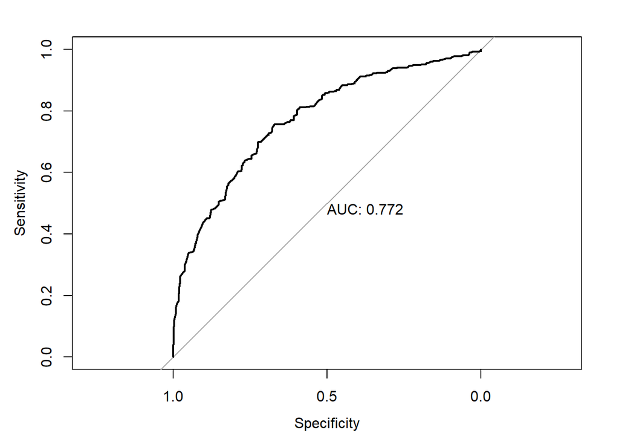

```r
On_board_Services_model_probs <- predict(On_board_Services_model, testX, type = "response")

On_board_Services_model_model_roc <- roc(test$Satisfaction ~ On_board_Services_model_probs, plot=TRUE, print.auc=TRUE)
```

Returns all information for the classification threshold of 0.5.

```r
coords(On_board_Services_model_model_roc, x=0.5, ret="all")
```

```
##           threshold specificity sensitivity  accuracy    tn   tp   fn   fp
## threshold       0.5   0.7743593   0.6292882 0.7111111 11301 7099 4182 3293
##                 npv       ppv       fdr       fpr       tpr       tnr       fnr
## threshold 0.7298973 0.6831216 0.3168784 0.2256407 0.6292882 0.7743593 0.3707118
##           1-specificity 1-sensitivity 1-accuracy     1-npv     1-ppv precision
## threshold     0.2256407     0.3707118  0.2888889 0.2701027 0.3168784 0.6831216
##              recall   youden closest.topleft
## threshold 0.6292882 1.403648        0.188341
```

Returns all information for the classification usign the best threshold.

```r
coords(On_board_Services_model_model_roc, x="best", ret="all")
```

```
##           threshold specificity sensitivity  accuracy   tn   tp   fn   fp
## threshold 0.4074128   0.6721255   0.7556954 0.7085604 9809 8525 2756 4785
##                 npv       ppv       fdr       fpr       tpr       tnr       fnr
## threshold 0.7806606 0.6404959 0.3595041 0.3278745 0.7556954 0.6721255 0.2443046
##           1-specificity 1-sensitivity 1-accuracy     1-npv     1-ppv precision
## threshold     0.3278745     0.2443046  0.2914396 0.2193394 0.3595041 0.6404959
##              recall   youden closest.topleft
## threshold 0.7556954 1.427821       0.1671864
```

Check the collinearity between predictors in a regression model. Collinearity occurs when two or more predictors in a model are highly correlated.

```r
check_collinearity <- vif(On_board_Services_model)
check_collinearity
```

```
##          Food.and.Drink       In.flight.Service  In.flight.Wifi.Service
##                1.755596                1.173156                1.003097
## In.flight.Entertainment
##                1.927403
```

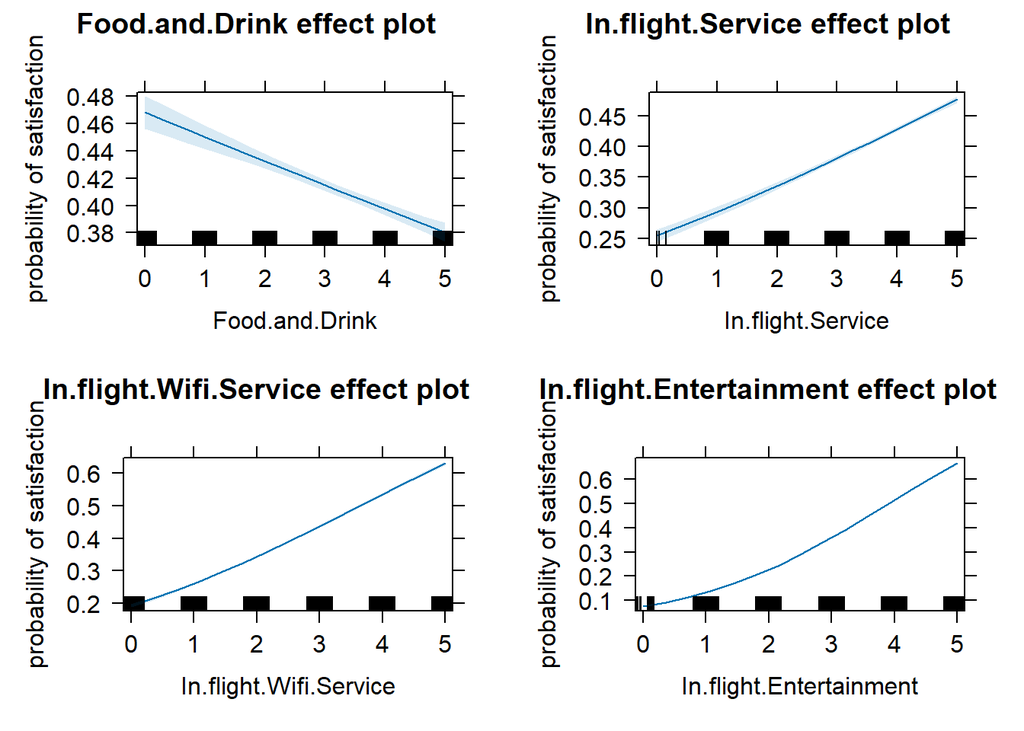

```r
plot(allEffects(On_board_Services_model), ylab="probability of satisfaction", rescale.axis=FALSE)
```

Let us perform some inference to see how the probability of being satisfied changes.

```r
testX[12,]
```

```
##    Gender Age Customer.Type Type.of.Travel    Class Flight.Distance
## 59 Female  41     Returning       Business Business            3997
##    Departure.and.Arrival.Time.Convenience Ease.of.Online.Booking
## 59                                      1                      1
##    Check.in.Service Online.Boarding Gate.Location On.board.Service Seat.Comfort
## 59                5               4             1                4            5
##    Leg.Room.Service Cleanliness Food.and.Drink In.flight.Service
## 59                4           4              4                 4
##    In.flight.Wifi.Service In.flight.Entertainment Baggage.Handling Delay
## 59                      1                       4                5   0.5
```

```r
test12<-testX[12,]
pred1.probs <- predict(On_board_Services_model, test12, type = "response")
pred1.probs
```

```
##        59
## 0.3511894
```

```r
i1 <- predict(On_board_Services_model, test12, type = "response", se.fit = TRUE)
lo1 <- i1$fit - qnorm(0.975) * i1$se
up1 <- i1$fit + qnorm(0.975) * i1$se
c(lo1, up1)
```

```
##        59        59
## 0.3453828 0.3569959
```

```r
test12$In.flight.Service<-5
pred2.probs <- predict(On_board_Services_model, test12, type = "response")
pred2.probs
```

```
##        59
## 0.3971869
```

```r
i2 <- predict(On_board_Services_model, test12, type = "response", se.fit = TRUE)
lo2 <- i2$fit - qnorm(0.975) * i2$se
up2 <- i2$fit + qnorm(0.975) * i2$se
c(lo2, up2)
```

```
##        59        59
## 0.3899549 0.4044189
```

```r
test12$In.flight.Wifi.Service<-4
pred3.probs <- predict(On_board_Services_model, test12, type = "response")
pred3.probs
```

```
##        59
## 0.6818493
```

```r
i3 <- predict(On_board_Services_model, test12, type = "response", se.fit = TRUE)
lo3 <- i3$fit - qnorm(0.975) * i3$se
up3 <- i3$fit + qnorm(0.975) * i3$se
c(lo3, up3)
```

```
##        59        59
## 0.6760761 0.6876225
```

What we can see is that on-board entertainment can significantly increase customer satisfaction with the food and services offered. Also, although strange, we can see that as the quality of food and drink increases, the likelihood of satisfaction decreases.

## 5.5 Comfort and Cleanliness Model

This model calculates passenger satisfaction based on the comfort and cleanliness of the aircraft.

```r
Comfort_and_Cleanliness_model <- glm(Satisfaction ~ Seat.Comfort + Leg.Room.Service + Cleanliness, data = train, family = binomial)

summary(Comfort_and_Cleanliness_model)
```

```
##
## Call:
## glm(formula = Satisfaction ~ Seat.Comfort + Leg.Room.Service +
##     Cleanliness, family = binomial, data = train)
##
## Coefficients:
##                   Estimate Std. Error z value Pr(>|z|)
## (Intercept)      -4.395153   0.032360 -135.82   <2e-16 ***
## Seat.Comfort      0.451909   0.007403   61.05   <2e-16 ***
## Leg.Room.Service  0.520089   0.005721   90.91   <2e-16 ***
## Cleanliness       0.224718   0.007293   30.81   <2e-16 ***
## ---
## Signif. codes:  0 '***' 0.001 '**' 0.01 '*' 0.05 '.' 0.1 ' ' 1
##
## (Dispersion parameter for binomial family taken to be 1)
##
##     Null deviance: 141833  on 103611  degrees of freedom
## Residual deviance: 118115  on 103608  degrees of freedom
## AIC: 118123
##
## Number of Fisher Scoring iterations: 4
```

Below the execution of the test set with the current model:

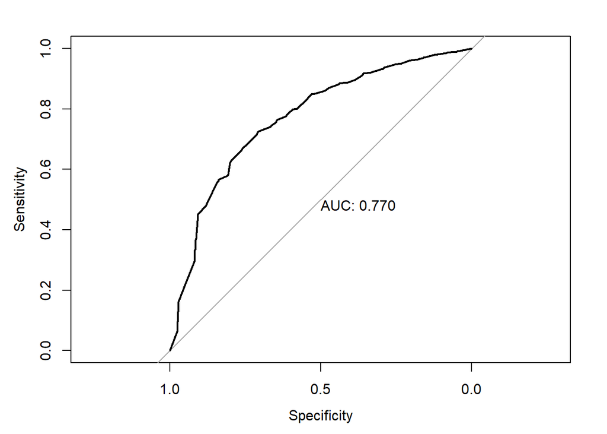

```r
Comfort_and_Cleanliness_model_probs <- predict(Comfort_and_Cleanliness_model, testX, type = "response")

Comfort_and_Cleanliness_model_roc <- roc(test$Satisfaction ~ Comfort_and_Cleanliness_model_probs, plot=TRUE, print.auc=TRUE)
```

Returns all information for the classification threshold of 0.5.

```r
coords(Comfort_and_Cleanliness_model_roc, x=0.5, ret="all")
```

```
##           threshold specificity sensitivity  accuracy    tn   tp   fn   fp
## threshold       0.5   0.7590106   0.6703306 0.7203478 11077 7562 3719 3517
##                 npv       ppv       fdr       fpr       tpr       tnr       fnr
## threshold 0.7486483 0.6825526 0.3174474 0.2409894 0.6703306 0.7590106 0.3296694
##           1-specificity 1-sensitivity 1-accuracy     1-npv     1-ppv precision
## threshold     0.2409894     0.3296694  0.2796522 0.2513517 0.3174474 0.6825526
##              recall   youden closest.topleft
## threshold 0.6703306 1.429341       0.1667578
```

Returns all information for the classification usign the best threshold.

```r
coords(Comfort_and_Cleanliness_model_roc, x="best", ret="all")
```

```
##           threshold specificity sensitivity  accuracy    tn   tp   fn   fp
## threshold 0.4295523   0.7052213   0.7264427 0.7144734 10292 8195 3086 4302
##                 npv       ppv       fdr       fpr       tpr       tnr       fnr
## threshold 0.7693228 0.6557574 0.3442426 0.2947787 0.7264427 0.7052213 0.2735573
##           1-specificity 1-sensitivity 1-accuracy     1-npv     1-ppv precision
## threshold     0.2947787     0.2735573  0.2855266 0.2306772 0.3442426 0.6557574
##              recall   youden closest.topleft
## threshold 0.7264427 1.431664       0.1617281
```

Check the collinearity between predictors in a regression model. Collinearity occurs when two or more predictors in a model are highly correlated.

```r
check_collinearity <- vif(Comfort_and_Cleanliness_model)
check_collinearity
```

```
##     Seat.Comfort Leg.Room.Service      Cleanliness
##         1.609561         1.007228         1.607176
```

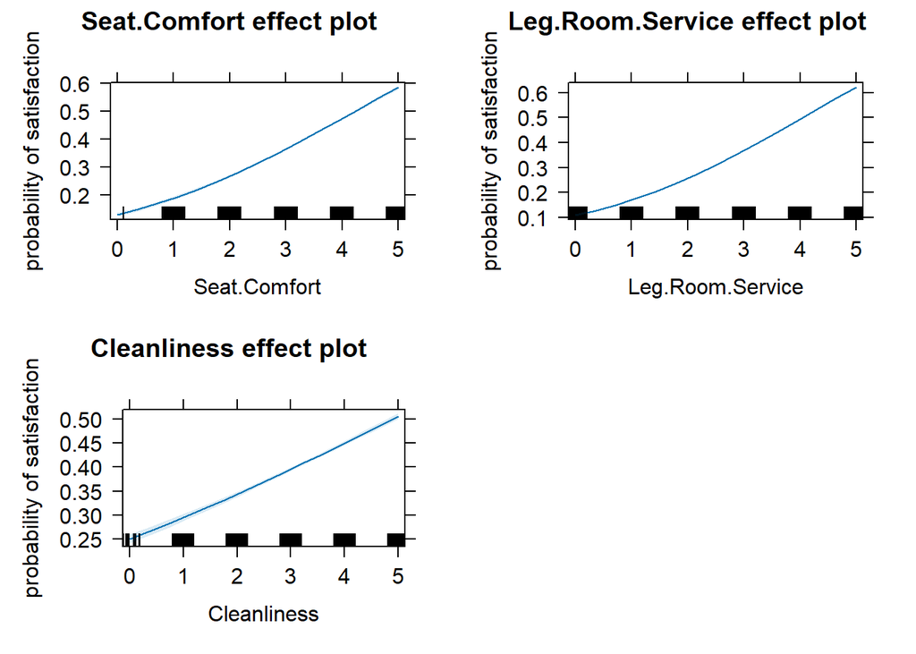

```r
plot(allEffects(Comfort_and_Cleanliness_model), ylab="probability of satisfaction", rescale.axis=FALSE)
```

Let us perform some inference to see how the probability of being satisfied changes.

```r
testX[12,]
```

```
##    Gender Age Customer.Type Type.of.Travel    Class Flight.Distance
## 59 Female  41     Returning       Business Business            3997
##    Departure.and.Arrival.Time.Convenience Ease.of.Online.Booking
## 59                                      1                      1
##    Check.in.Service Online.Boarding Gate.Location On.board.Service Seat.Comfort
## 59                5               4             1                4            5
##    Leg.Room.Service Cleanliness Food.and.Drink In.flight.Service
## 59                4           4              4                 4
##    In.flight.Wifi.Service In.flight.Entertainment Baggage.Handling Delay
## 59                      1                       4                5   0.5
```

```r
test12<-testX[12,]
pred1.probs <- predict(Comfort_and_Cleanliness_model, test12, type = "response")
pred1.probs
```

```
##        59
## 0.6992275
```

```r
i1 <- predict(Comfort_and_Cleanliness_model, test12, type = "response", se.fit = TRUE)
lo1 <- i1$fit - qnorm(0.975) * i1$se
up1 <- i1$fit + qnorm(0.975) * i1$se
c(lo1, up1)
```

```
##        59        59
## 0.6944874 0.7039676
```

```r
test12$Cleanliness<-1
pred2.probs <- predict(Comfort_and_Cleanliness_model, test12, type = "response")
pred2.probs
```

```
##        59
## 0.5422656
```

```r
i2 <- predict(Comfort_and_Cleanliness_model, test12, type = "response", se.fit = TRUE)
lo2 <- i2$fit - qnorm(0.975) * i2$se
up2 <- i2$fit + qnorm(0.975) * i2$se
c(lo2, up2)
```

```
##        59        59
## 0.5293779 0.5551532
```

```r
test12$Seat.Comfort<-1
pred3.probs <- predict(Comfort_and_Cleanliness_model, test12, type = "response")
pred3.probs
```

```
##        59
## 0.1627144
```

```r
i3 <- predict(Comfort_and_Cleanliness_model, test12, type = "response", se.fit = TRUE)
lo3 <- i3$fit - qnorm(0.975) * i3$se
up3 <- i3$fit + qnorm(0.975) * i3$se
c(lo3, up3)
```

```
##        59        59
## 0.1579364 0.1674924
```

The trend of the variables is very similar, as the rating increases, the likelihood of increasing satisfaction increases. Slightly more important are seat comfort and leg room services.

## 5.6 Airport Services Model

This model calculates passenger satisfaction based on the services offered by the airport.

```r
Airport_Services_model <- glm(Satisfaction ~ Gate.Location + On.board.Service + Baggage.Handling + Check.in.Service + Online.Boarding, data = train, family = binomial)

summary(Airport_Services_model)
```

```
##
## Call:
## glm(formula = Satisfaction ~ Gate.Location + On.board.Service +
##     Baggage.Handling + Check.in.Service + Online.Boarding, family = binomial,
##     data = train)
##
## Coefficients:
##                   Estimate Std. Error z value Pr(>|z|)
## (Intercept)      -6.299000   0.046129 -136.55   <2e-16 ***
## Gate.Location     0.010741   0.006001    1.79   0.0735 .
## On.board.Service  0.401999   0.007355   54.65   <2e-16 ***
## Baggage.Handling  0.224646   0.007766   28.93   <2e-16 ***
## Check.in.Service  0.168706   0.006469   26.08   <2e-16 ***
## Online.Boarding   0.950992   0.007140  133.19   <2e-16 ***
## ---
## Signif. codes:  0 '***' 0.001 '**' 0.01 '*' 0.05 '.' 0.1 ' ' 1
##
## (Dispersion parameter for binomial family taken to be 1)
##
##     Null deviance: 141833  on 103611  degrees of freedom
## Residual deviance: 102027  on 103606  degrees of freedom
## AIC: 102039
##
## Number of Fisher Scoring iterations: 5
```

Below the execution of the test set with the current model:

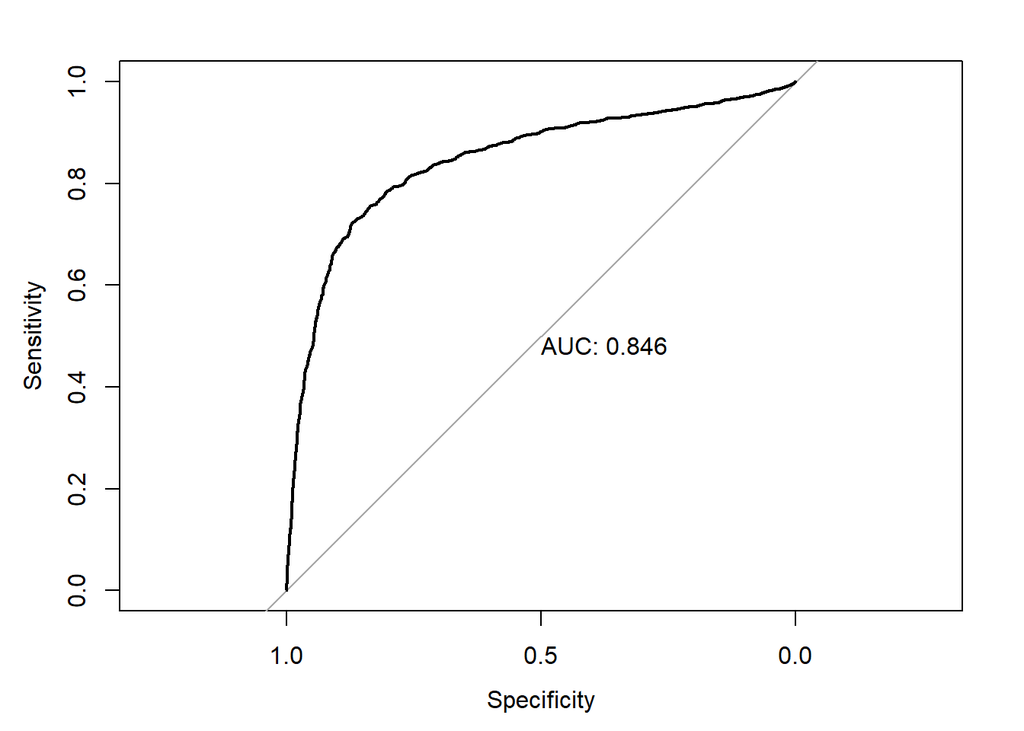

```r
Airport_Services_model_probs <- predict(Airport_Services_model, testX, type = "response")

Airport_Services_model_roc <- roc(test$Satisfaction ~ Airport_Services_model_probs, plot=TRUE, print.auc=TRUE)
```

Returns all information for the classification threshold of 0.5.

```r
coords(Airport_Services_model_roc, x=0.5, ret="all")
```

```
##           threshold specificity sensitivity  accuracy    tn   tp   fn   fp
## threshold       0.5   0.8307524   0.7570251 0.7986087 12124 8540 2741 2470
##                 npv       ppv       fdr       fpr       tpr       tnr       fnr
## threshold 0.8156071 0.7756585 0.2243415 0.1692476 0.7570251 0.8307524 0.2429749
##           1-specificity 1-sensitivity 1-accuracy     1-npv     1-ppv precision
## threshold     0.1692476     0.2429749  0.2013913 0.1843929 0.2243415 0.7756585
##              recall   youden closest.topleft
## threshold 0.7570251 1.587777      0.08768157
```

Returns all information for the classification usign the best threshold.

```r
coords(Airport_Services_model_roc, x="best", ret="all")
```

```
##           threshold specificity sensitivity accuracy    tn   tp   fn   fp
## threshold 0.5562179    0.871317   0.7215672 0.806029 12716 8140 3141 1878
##                 npv       ppv       fdr      fpr       tpr      tnr       fnr
## threshold 0.8019171 0.8125374 0.1874626 0.128683 0.7215672 0.871317 0.2784328
##           1-specificity 1-sensitivity 1-accuracy     1-npv     1-ppv precision
## threshold      0.128683     0.2784328   0.193971 0.1980829 0.1874626 0.8125374
##              recall   youden closest.topleft
## threshold 0.7215672 1.592884      0.09408412
```

Check the collinearity between predictors in a regression model. Collinearity occurs when two or more predictors in a model are highly correlated.

```r
check_collinearity <- vif(Airport_Services_model)
check_collinearity
```

```
##    Gate.Location On.board.Service Baggage.Handling Check.in.Service
##         1.002272         1.328579         1.341233         1.048824
##  Online.Boarding
##         1.023246
```

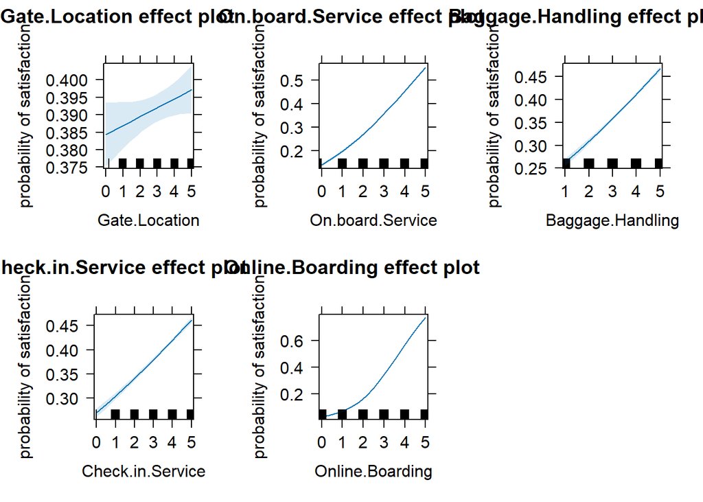

```r
plot(allEffects(Airport_Services_model), ylab="probability of satisfaction", rescale.axis=FALSE)
```

Let us perform some inference to see how the probability of being satisfied changes.

```r
testX[12,]
```

```
##    Gender Age Customer.Type Type.of.Travel    Class Flight.Distance
## 59 Female  41     Returning       Business Business            3997
##    Departure.and.Arrival.Time.Convenience Ease.of.Online.Booking
## 59                                      1                      1
##    Check.in.Service Online.Boarding Gate.Location On.board.Service Seat.Comfort
## 59                5               4             1                4            5
##    Leg.Room.Service Cleanliness Food.and.Drink In.flight.Service
## 59                4           4              4                 4
##    In.flight.Wifi.Service In.flight.Entertainment Baggage.Handling Delay
## 59                      1                       4                5   0.5
```

```r
test12<-testX[12,]
pred1.probs <- predict(Airport_Services_model, test12, type = "response")
pred1.probs
```

```
##        59
## 0.7484695
```

```r
i1 <- predict(Airport_Services_model, test12, type = "response", se.fit = TRUE)
lo1 <- i1$fit - qnorm(0.975) * i1$se
up1 <- i1$fit + qnorm(0.975) * i1$se
c(lo1, up1)
```

```
##        59        59
## 0.7414383 0.7555007
```

```r
test12$Baggage.Handling<-1
pred2.probs <- predict(Airport_Services_model, test12, type = "response")
pred2.probs
```

```
##       59
## 0.547824
```

```r
i2 <- predict(Airport_Services_model, test12, type = "response", se.fit = TRUE)
lo2 <- i2$fit - qnorm(0.975) * i2$se
up2 <- i2$fit + qnorm(0.975) * i2$se
c(lo2, up2)
```

```
##        59        59
## 0.5336557 0.5619923
```

```r
test12$Online.Boarding<-1
pred3.probs <- predict(Airport_Services_model, test12, type = "response")
pred3.probs
```

```
##        59
## 0.0653086
```

```r
i3 <- predict(Airport_Services_model, test12, type = "response", se.fit = TRUE)
lo3 <- i3$fit - qnorm(0.975) * i3$se
up3 <- i3$fit + qnorm(0.975) * i3$se
c(lo3, up3)
```

```
##         59         59
## 0.06104709 0.06957011
```

Excluding Gate location, which does not bring major changes, all other variables increase the probability of satisfaction to the increase of its value.

## 5.7 Demographic variables Model

This model calculates passenger satisfaction according to age.

```r
Demographic_variables_model <- glm(Satisfaction ~ Age, data = train, family = binomial)

summary(Demographic_variables_model)
```

```
##
## Call:
## glm(formula = Satisfaction ~ Age, family = binomial, data = train)
##
## Coefficients:
##               Estimate Std. Error z value Pr(>|z|)
## (Intercept) -0.9894751  0.0180842  -54.72   <2e-16 ***
## Age          0.0182384  0.0004237   43.05   <2e-16 ***
## ---
## Signif. codes:  0 '***' 0.001 '**' 0.01 '*' 0.05 '.' 0.1 ' ' 1
##
## (Dispersion parameter for binomial family taken to be 1)
##
##     Null deviance: 141833  on 103611  degrees of freedom
## Residual deviance: 139940  on 103610  degrees of freedom
## AIC: 139944
##
## Number of Fisher Scoring iterations: 4
```

Below the execution of the test set with the current model:

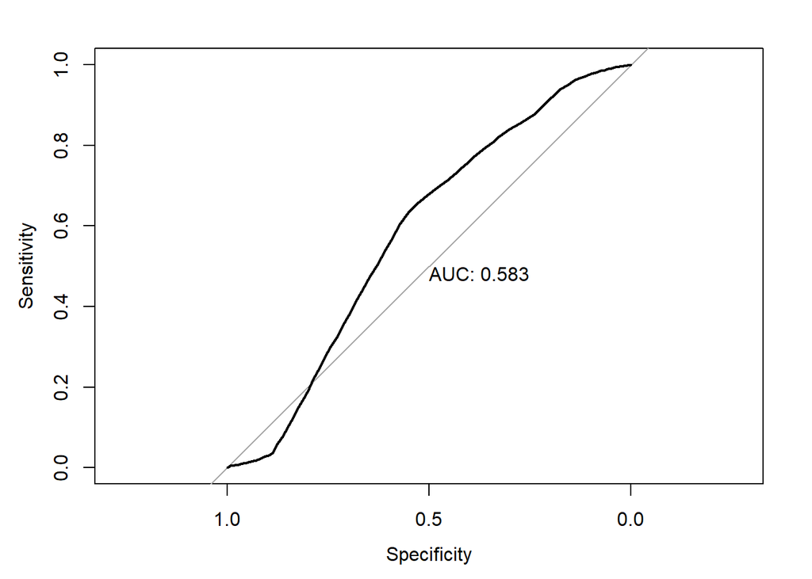

```r
Demographic_variables_model_probs <- predict(Demographic_variables_model, testX, type = "response")

Demographic_variables_model_roc <- roc(test$Satisfaction ~ Demographic_variables_model_probs, plot=TRUE, print.auc=TRUE)
```

Returns all information for the classification threshold of 0.5.

```r
coords(Demographic_variables_model_roc, x=0.5, ret="all")
```

```
##           threshold specificity sensitivity  accuracy    tn   tp   fn   fp
## threshold       0.5    0.812046   0.1686907 0.5315556 11851 1903 9378 2743
##                 npv       ppv       fdr      fpr       tpr      tnr       fnr
## threshold 0.5582458 0.4095997 0.5904003 0.187954 0.1686907 0.812046 0.8313093
##           1-specificity 1-sensitivity 1-accuracy     1-npv     1-ppv precision
## threshold      0.187954     0.8313093  0.4684444 0.4417542 0.5904003 0.4095997
##              recall    youden closest.topleft
## threshold 0.1686907 0.9807368       0.7264018
```

Returns all information for the classification usign the best threshold.

```r
coords(Demographic_variables_model_roc, x="best", ret="all")
```

```
##           threshold specificity sensitivity accuracy   tn   tp   fn   fp
## threshold  0.428667    0.548102   0.6382413 0.587401 7999 7200 4081 6595
##                 npv       ppv       fdr      fpr       tpr      tnr       fnr
## threshold 0.6621689 0.5219282 0.4780718 0.451898 0.6382413 0.548102 0.3617587
##           1-specificity 1-sensitivity 1-accuracy     1-npv     1-ppv precision
## threshold      0.451898     0.3617587   0.412599 0.3378311 0.4780718 0.5219282
##              recall   youden closest.topleft
## threshold 0.6382413 1.186343       0.3350812
```

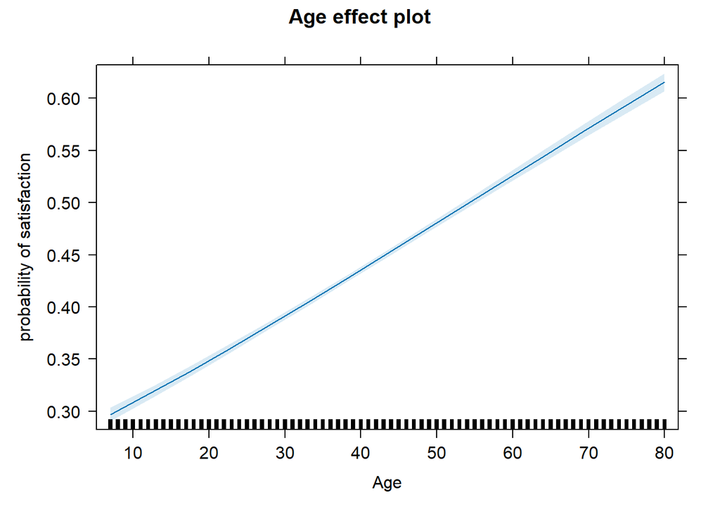

```r
plot(allEffects(Demographic_variables_model), ylab="probability of satisfaction", rescale.axis=FALSE)
```

```r
testX[12,]
```

```
##    Gender Age Customer.Type Type.of.Travel    Class Flight.Distance
## 59 Female  41     Returning       Business Business            3997
##    Departure.and.Arrival.Time.Convenience Ease.of.Online.Booking
## 59                                      1                      1
##    Check.in.Service Online.Boarding Gate.Location On.board.Service Seat.Comfort
## 59                5               4             1                4            5
##    Leg.Room.Service Cleanliness Food.and.Drink In.flight.Service
## 59                4           4              4                 4
##    In.flight.Wifi.Service In.flight.Entertainment Baggage.Handling Delay
## 59                      1                       4                5   0.5
```

Let us perform some inference to see how the probability of being satisfied changes.

```r
test12<-testX[12,]
pred1.probs <- predict(Demographic_variables_model, test12, type = "response")
pred1.probs
```

```
##       59
## 0.439867
```

```r
i1 <- predict(Demographic_variables_model, test12, type = "response", se.fit = TRUE)
lo1 <- i1$fit - qnorm(0.975) * i1$se
up1 <- i1$fit + qnorm(0.975) * i1$se
c(lo1, up1)
```

```
##        59        59
## 0.4368053 0.4429287
```

From 41 to 20

```r
test12$Age<-20
pred2.probs <- predict(Demographic_variables_model, test12, type = "response")
pred2.probs
```

```
##        59
## 0.3487115
```

```r
i2 <- predict(Demographic_variables_model, test12, type = "response", se.fit = TRUE)
lo2 <- i2$fit - qnorm(0.975) * i2$se
up2 <- i2$fit + qnorm(0.975) * i2$se
c(lo2, up2)
```

```
##        59        59
## 0.3440063 0.3534167
```

The results show that increasing age can lead to better passenger satisfaction.

## 5.8 Summary of results

Below is a table summarising all the results of previous models:

```
##                              Model      AIC       AUC Threshold.Accuracy.0.5
## 1         Customer and Travel Type 100250.3 0.8304345                  0.780
## 2                Time and Distance 131984.2 0.6545085                  0.659
## 3 Convenience and Booking Services 136509.6 0.6315613                  0.590
## 4                On-board Services 117722.6 0.7723436                  0.711
## 5          Comfort and Cleanliness 118122.7 0.7702107                  0.720
## 6                 Airport Services 102039.1 0.8464938                  0.798
## 7            Demographic variables 139944.1 0.5833330                  0.531
##   Best.Threshold N.of.predictors
## 1          0.773               3
## 2          0.659               2
## 3          0.561               1
## 4          0.708               4
## 5          0.714               3
## 6          0.806               5
## 7          0.587               1
```

AIC is a measure of the relative entropy of a model, i.e. the amount of information lost when using the model to describe the data. A lower AIC value indicates a better model. The model with the lowest AIC is considered the best of those compared.

Providing services of a certain level within the airport leads to higher customer satisfaction. From the table, we can see that other categories are valid for evaluating customer satisfaction, such as Customer and Travel Type, which show results very close to the best model.

Several categories can therefore influence customer satisfaction.

An initial analysis shows that the services offered by the airport, the services offered on board, comfort, cleanliness and travel type are the categories that most influence customer satisfaction.

For each model, we performed an inference to see how, as the value of a predictor changes, the probability of achieving customer satisfaction also changes. Some variables lead to a high increase in probability, some others slightly change the results.

What we can do now is to create slightly more complex models that combine more variables.

Now I will focus on the following classes:

- `Customer and Travel Type`: Customer.Type, Type.of.Travel, Class.
- `On-board Services`: Food.and.Drink, In.flight.Service, In.flight.Wifi.Service, In.flight.Entertainment.
- `Comfort and Cleanliness`: Seat.Comfort, Leg.Room.Service, Cleanliness.
- `Airport Services`: Gate.Location, On.board.Service, Baggage.Handling, Check.in.Service, Online.Boarding.

# 6 Combination models

We are now going to combine the previous models.

## 6.1 Airport Services + Customer and Travel Type

Let’s combine the two models with the best results using 8 predictor in total.

```r
AS_CTT_model <- glm(Satisfaction ~ Gate.Location + On.board.Service + Baggage.Handling + Check.in.Service + Online.Boarding + Customer.Type + Type.of.Travel + Class , data = train, family = binomial)

summary(AS_CTT_model)
```

```
##
## Call:
## glm(formula = Satisfaction ~ Gate.Location + On.board.Service +
##     Baggage.Handling + Check.in.Service + Online.Boarding + Customer.Type +
##     Type.of.Travel + Class, family = binomial, data = train)
##
## Coefficients:
##                         Estimate Std. Error  z value Pr(>|z|)
## (Intercept)            -7.143104   0.063018 -113.351  < 2e-16 ***
## Gate.Location          -0.022861   0.007030   -3.252  0.00115 **
## On.board.Service        0.413389   0.008826   46.837  < 2e-16 ***
## Baggage.Handling        0.347630   0.009522   36.506  < 2e-16 ***
## Check.in.Service        0.324998   0.007914   41.068  < 2e-16 ***
## Online.Boarding         0.794416   0.008217   96.679  < 2e-16 ***
## Customer.TypeReturning  1.904611   0.025647   74.263  < 2e-16 ***
## Type.of.TravelPersonal -3.017817   0.029253 -103.162  < 2e-16 ***
## ClassEconomy           -0.507626   0.022285  -22.779  < 2e-16 ***
## ClassEconomy Plus      -0.557104   0.036955  -15.075  < 2e-16 ***
## ---
## Signif. codes:  0 '***' 0.001 '**' 0.01 '*' 0.05 '.' 0.1 ' ' 1
##
## (Dispersion parameter for binomial family taken to be 1)
##
##     Null deviance: 141833  on 103611  degrees of freedom
## Residual deviance:  74688  on 103602  degrees of freedom
## AIC: 74708
##
## Number of Fisher Scoring iterations: 5
```

Below the execution of the test set with the current model:

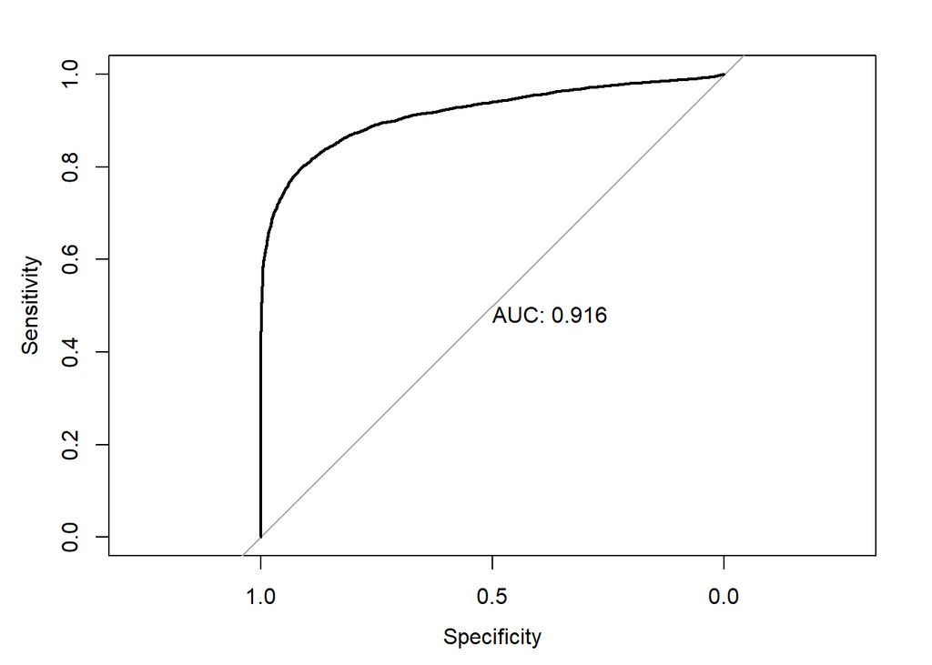

```r
AS_CTT_model_probs <- predict(AS_CTT_model, testX, type = "response")

AS_CTT_model_roc <- roc(test$Satisfaction ~ AS_CTT_model_probs, plot=TRUE, print.auc=TRUE)
```

Returns all information for the classification threshold of 0.5.

```r
coords(AS_CTT_model_roc, x=0.5, ret="all")
```

```
##           threshold specificity sensitivity  accuracy    tn   tp   fn   fp
## threshold       0.5   0.8966013   0.8092368 0.8585121 13085 9129 2152 1509
##                 npv     ppv     fdr       fpr       tpr       tnr       fnr
## threshold 0.8587648 0.85815 0.14185 0.1033987 0.8092368 0.8966013 0.1907632
##           1-specificity 1-sensitivity 1-accuracy     1-npv   1-ppv precision
## threshold     0.1033987     0.1907632  0.1414879 0.1412352 0.14185   0.85815
##              recall   youden closest.topleft
## threshold 0.8092368 1.705838      0.04708189
```

Returns all information for the classification usign the best threshold.

```r
coords(AS_CTT_model_roc, x="best", ret="all")
```

```
##           threshold specificity sensitivity  accuracy    tn   tp   fn   fp
## threshold  0.543914   0.9139372   0.7967379 0.8628406 13338 8988 2293 1256
##                 npv       ppv       fdr        fpr       tpr       tnr
## threshold 0.8533043 0.8773916 0.1226084 0.08606277 0.7967379 0.9139372
##                 fnr 1-specificity 1-sensitivity 1-accuracy     1-npv     1-ppv
## threshold 0.2032621    0.08606277     0.2032621  0.1371594 0.1466957 0.1226084
##           precision    recall   youden closest.topleft
## threshold 0.8773916 0.7967379 1.710675      0.04872229
```

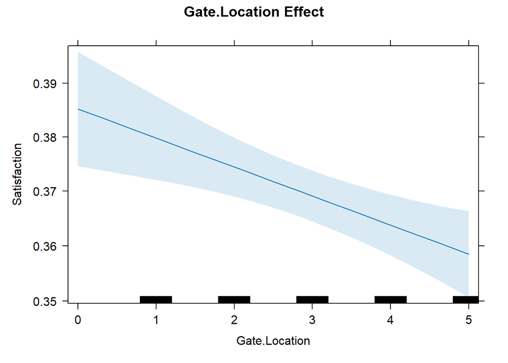

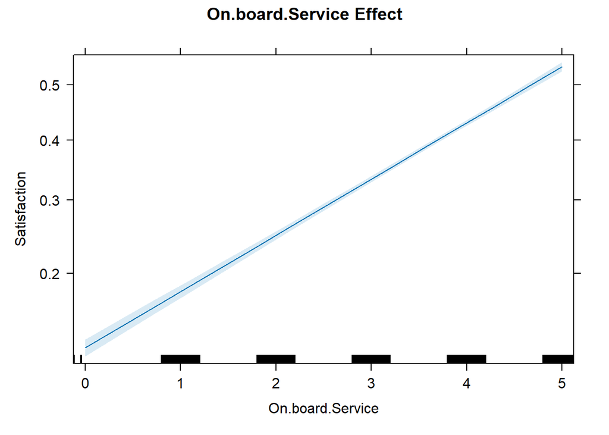

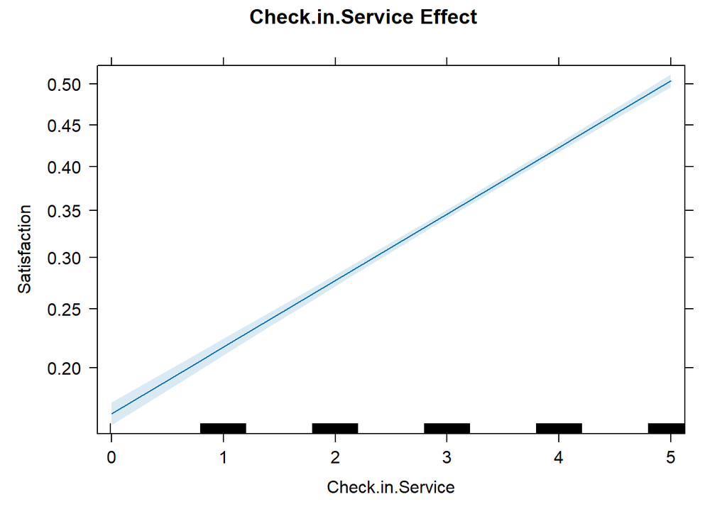

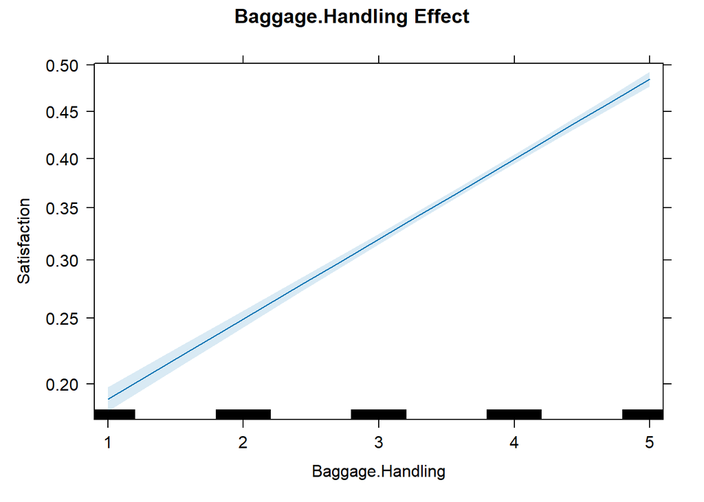

[figure not shown]

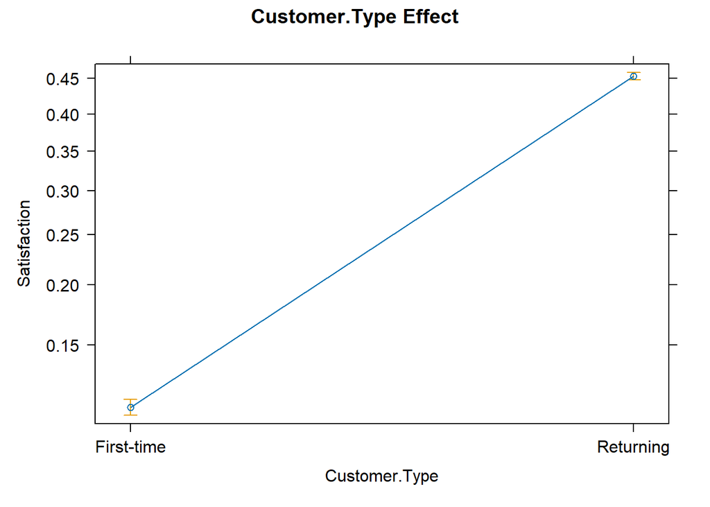

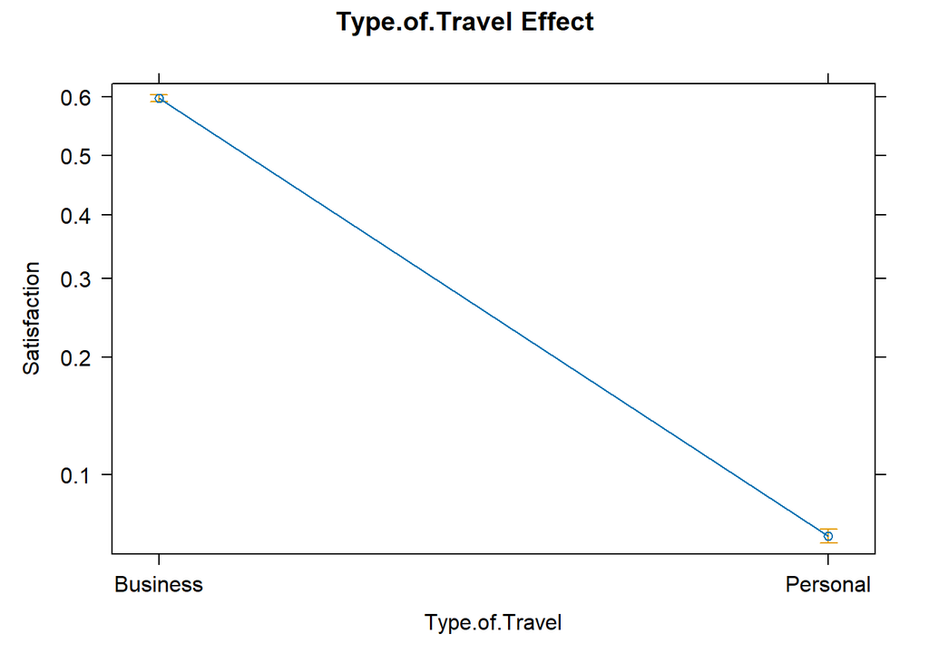

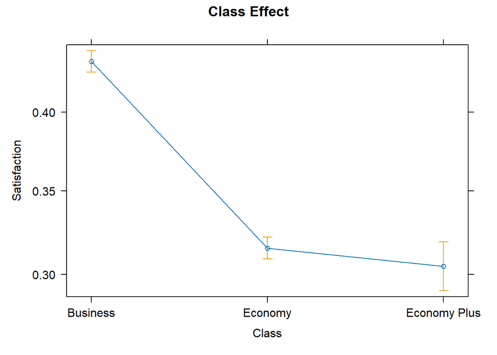

## 6.2 Airport Services + Comfort and Cleanliness

```r
AS_CC_model <- glm(Satisfaction ~  Gate.Location + On.board.Service + Baggage.Handling + Check.in.Service + Online.Boarding + Seat.Comfort + Leg.Room.Service + Cleanliness , data = train, family = binomial)

summary(AS_CC_model)
```

```
##
## Call:
## glm(formula = Satisfaction ~ Gate.Location + On.board.Service +
##     Baggage.Handling + Check.in.Service + Online.Boarding + Seat.Comfort +
##     Leg.Room.Service + Cleanliness, family = binomial, data = train)
##
## Coefficients:
##                   Estimate Std. Error  z value Pr(>|z|)
## (Intercept)      -7.766465   0.053606 -144.881   <2e-16 ***
## Gate.Location     0.007980   0.006251    1.277    0.202
## On.board.Service  0.324757   0.007641   42.500   <2e-16 ***
## Baggage.Handling  0.128426   0.008180   15.701   <2e-16 ***
## Check.in.Service  0.127708   0.006702   19.055   <2e-16 ***
## Online.Boarding   0.842612   0.007477  112.696   <2e-16 ***
## Seat.Comfort      0.200601   0.008514   23.562   <2e-16 ***
## Leg.Room.Service  0.399509   0.006819   58.590   <2e-16 ***
## Cleanliness       0.163080   0.008291   19.669   <2e-16 ***
## ---
## Signif. codes:  0 '***' 0.001 '**' 0.01 '*' 0.05 '.' 0.1 ' ' 1
##
## (Dispersion parameter for binomial family taken to be 1)
##
##     Null deviance: 141833  on 103611  degrees of freedom
## Residual deviance:  95881  on 103603  degrees of freedom
## AIC: 95899
##
## Number of Fisher Scoring iterations: 5
```

Below the execution of the test set with the current model:

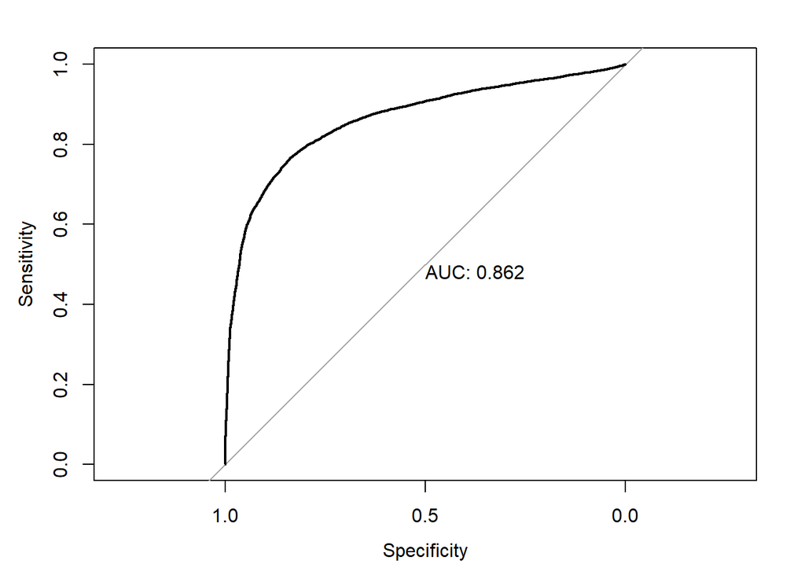

```r
AS_CC_model_probs <- predict(AS_CC_model, testX, type = "response")

AS_CC_model_roc <- roc(test$Satisfaction ~ AS_CC_model_probs, plot=TRUE, print.auc=TRUE)
```

Returns all information for the classification threshold of 0.5.

```r
coords(AS_CC_model_roc, x=0.5, ret="all")
```

```
##           threshold specificity sensitivity  accuracy    tn   tp   fn   fp
## threshold       0.5   0.8421269   0.7606595 0.8066087 12290 8581 2700 2304
##                 npv       ppv       fdr       fpr       tpr       tnr       fnr
## threshold 0.8198799 0.7883326 0.2116674 0.1578731 0.7606595 0.8421269 0.2393405
##           1-specificity 1-sensitivity 1-accuracy     1-npv     1-ppv precision
## threshold     0.1578731     0.2393405  0.1933913 0.1801201 0.2116674 0.7883326
##              recall   youden closest.topleft
## threshold 0.7606595 1.602786      0.08220778
```

Returns all information for the classification usign the best threshold.

```r
coords(AS_CC_model_roc, x="best", ret="all")
```

```
##           threshold specificity sensitivity  accuracy    tn   tp   fn   fp
## threshold 0.4926406   0.8373989   0.7657123 0.8061449 12221 8638 2643 2373
##                 npv       ppv       fdr       fpr       tpr       tnr       fnr
## threshold 0.8221878 0.7844882 0.2155118 0.1626011 0.7657123 0.8373989 0.2342877
##           1-specificity 1-sensitivity 1-accuracy     1-npv     1-ppv precision
## threshold     0.1626011     0.2342877  0.1938551 0.1778122 0.2155118 0.7844882
##              recall   youden closest.topleft
## threshold 0.7657123 1.603111      0.08132985
```

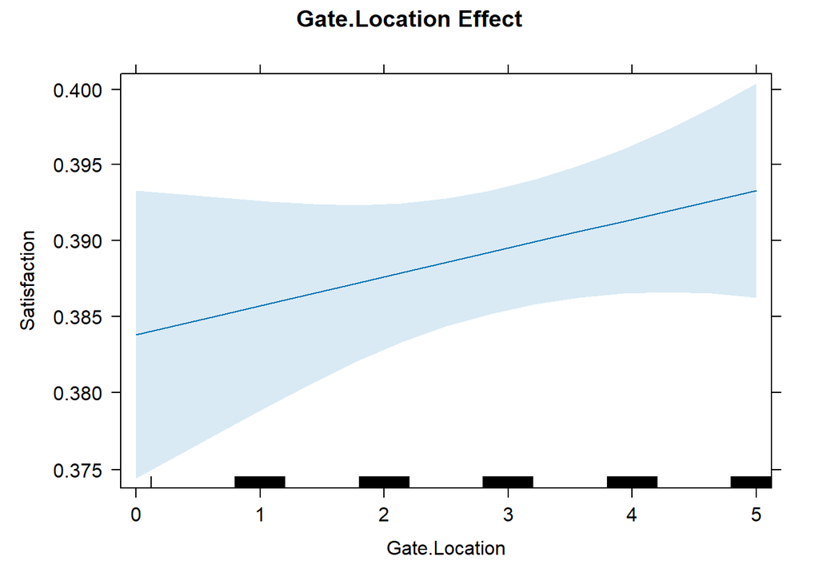

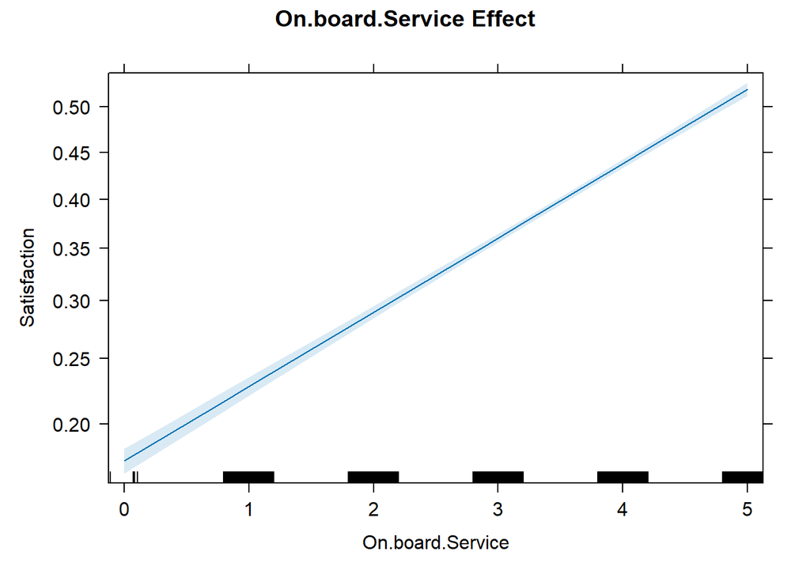

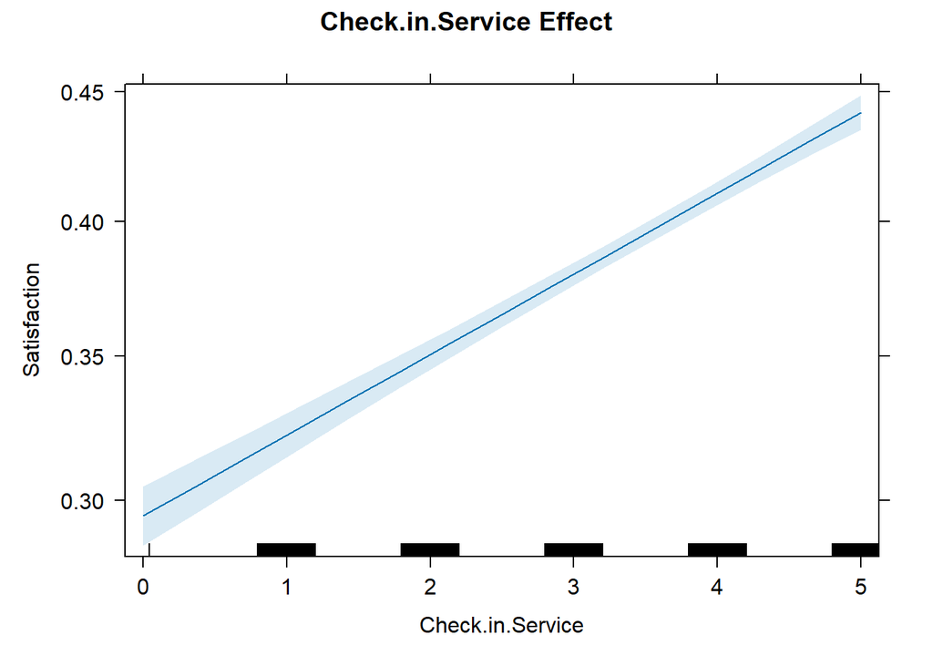

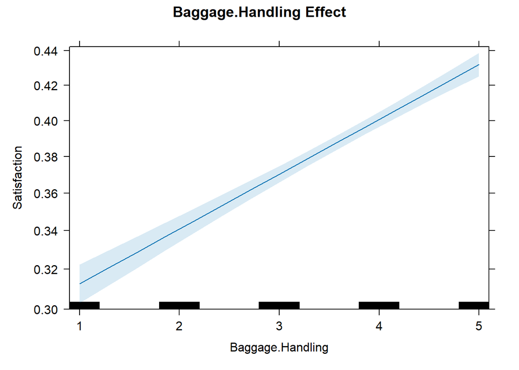

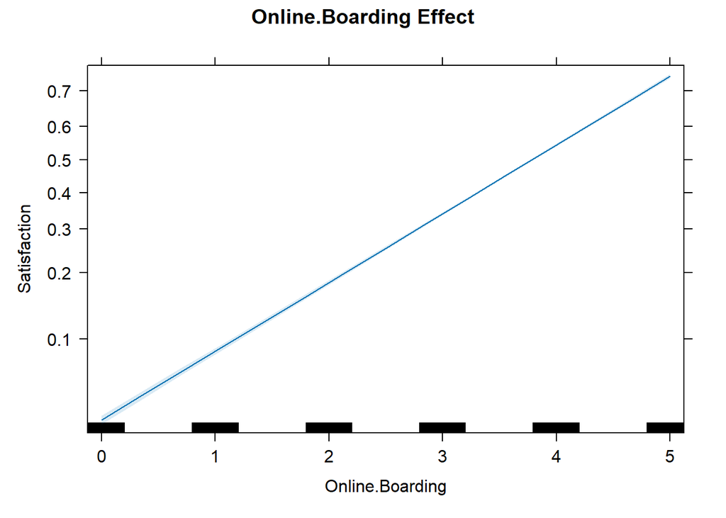

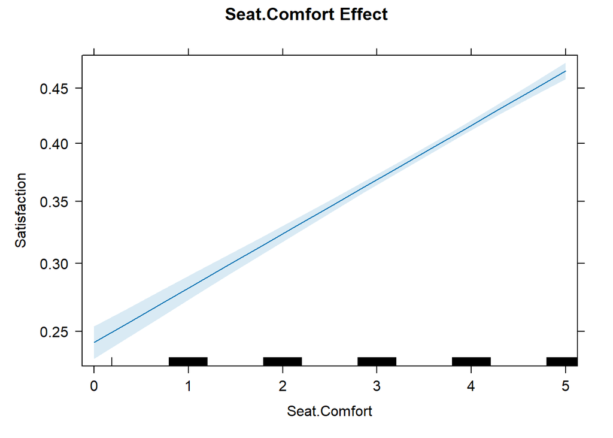

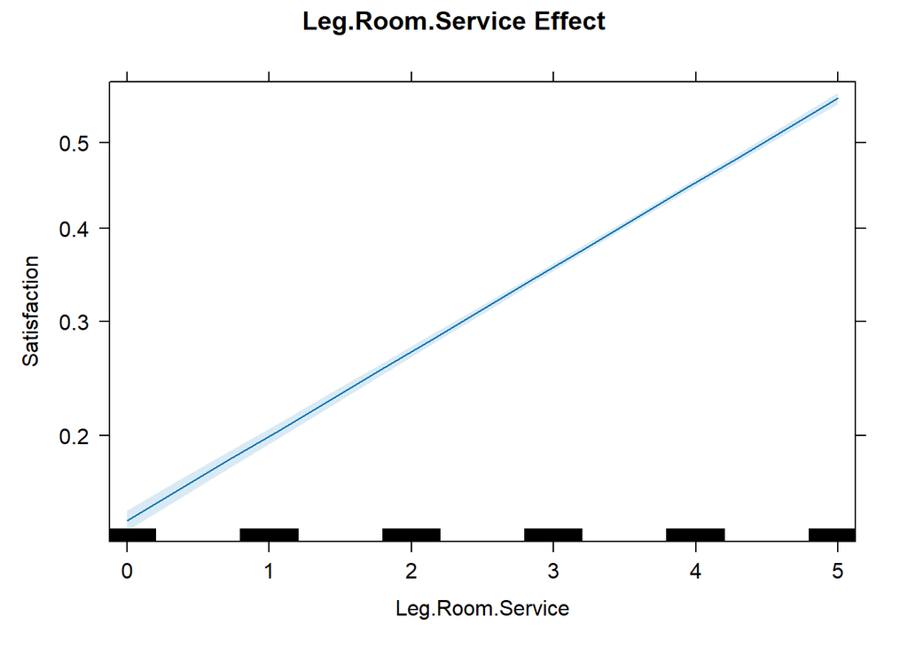

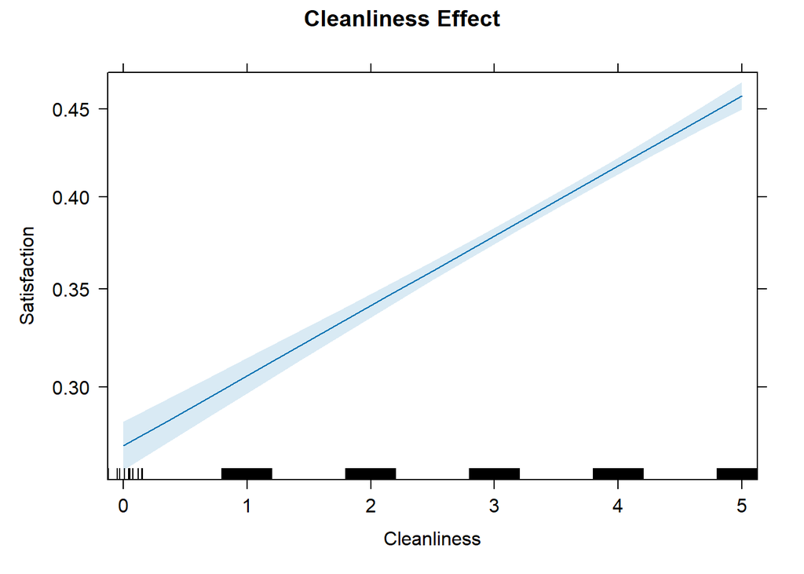

## 6.3 Airport Services + On-board Services

```r
AS_OBS_model <- glm(Satisfaction ~  Gate.Location + On.board.Service + Baggage.Handling + Check.in.Service + Online.Boarding + Food.and.Drink + In.flight.Service + In.flight.Wifi.Service + In.flight.Entertainment , data = train, family = binomial)

summary(AS_OBS_model)
```

```
##
## Call:
## glm(formula = Satisfaction ~ Gate.Location + On.board.Service +
##     Baggage.Handling + Check.in.Service + Online.Boarding + Food.and.Drink +
##     In.flight.Service + In.flight.Wifi.Service + In.flight.Entertainment,
##     family = binomial, data = train)
##
## Coefficients:
##                          Estimate Std. Error  z value Pr(>|z|)
## (Intercept)             -6.787179   0.051666 -131.366  < 2e-16 ***
## Gate.Location           -0.049604   0.006765   -7.332 2.26e-13 ***
## On.board.Service         0.266054   0.008206   32.422  < 2e-16 ***
## Baggage.Handling         0.090674   0.009082    9.983  < 2e-16 ***
## Check.in.Service         0.223848   0.006787   32.983  < 2e-16 ***
## Online.Boarding          0.822328   0.007732  106.348  < 2e-16 ***
## Food.and.Drink          -0.075867   0.008206   -9.245  < 2e-16 ***
## In.flight.Service        0.002842   0.009506    0.299    0.765
## In.flight.Wifi.Service   0.146498   0.007302   20.062  < 2e-16 ***
## In.flight.Entertainment  0.493853   0.009485   52.069  < 2e-16 ***
## ---
## Signif. codes:  0 '***' 0.001 '**' 0.01 '*' 0.05 '.' 0.1 ' ' 1
##
## (Dispersion parameter for binomial family taken to be 1)
##
##     Null deviance: 141833  on 103611  degrees of freedom
## Residual deviance:  97414  on 103602  degrees of freedom
## AIC: 97434
##
## Number of Fisher Scoring iterations: 5
```

Below the execution of the test set with the current model:

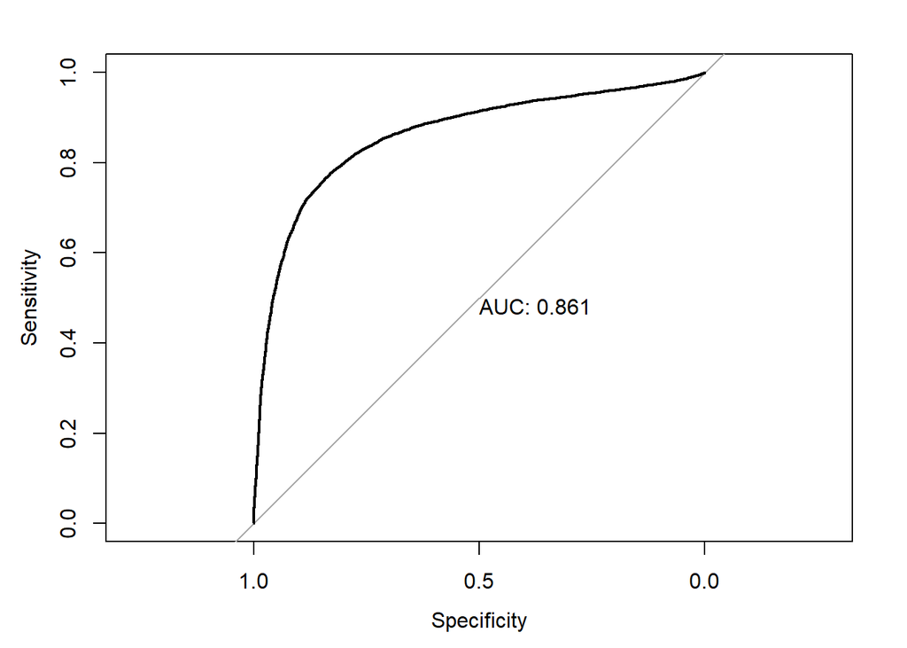

```r
AS_OBS_model_probs <- predict(AS_OBS_model, testX, type = "response")

AS_OBS_model_roc <- roc(test$Satisfaction ~ AS_OBS_model_probs, plot=TRUE, print.auc=TRUE)
```

Returns all information for the classification threshold of 0.5.

```r
coords(AS_OBS_model_roc, x=0.5, ret="all")
```

```
##           threshold specificity sensitivity  accuracy    tn   tp   fn   fp
## threshold       0.5   0.8365082    0.769258 0.8071884 12208 8678 2603 2386
##                 npv       ppv       fdr       fpr      tpr       tnr      fnr
## threshold 0.8242522 0.7843456 0.2156544 0.1634918 0.769258 0.8365082 0.230742
##           1-specificity 1-sensitivity 1-accuracy     1-npv     1-ppv precision
## threshold     0.1634918      0.230742  0.1928116 0.1757478 0.2156544 0.7843456
##             recall   youden closest.topleft
## threshold 0.769258 1.605766      0.07997143
```

Returns all information for the classification usign the best threshold.

```r
coords(AS_OBS_model_roc, x="best", ret="all")
```

```
##           threshold specificity sensitivity  accuracy    tn   tp   fn   fp
## threshold 0.4976774   0.8350692   0.7712082 0.8072271 12187 8700 2581 2407
##                 npv       ppv       fdr       fpr       tpr       tnr       fnr
## threshold 0.8252302 0.7832898 0.2167102 0.1649308 0.7712082 0.8350692 0.2287918
##           1-specificity 1-sensitivity 1-accuracy     1-npv     1-ppv precision
## threshold     0.1649308     0.2287918  0.1927729 0.1747698 0.2167102 0.7832898
##              recall   youden closest.topleft
## threshold 0.7712082 1.606277      0.07954784
```

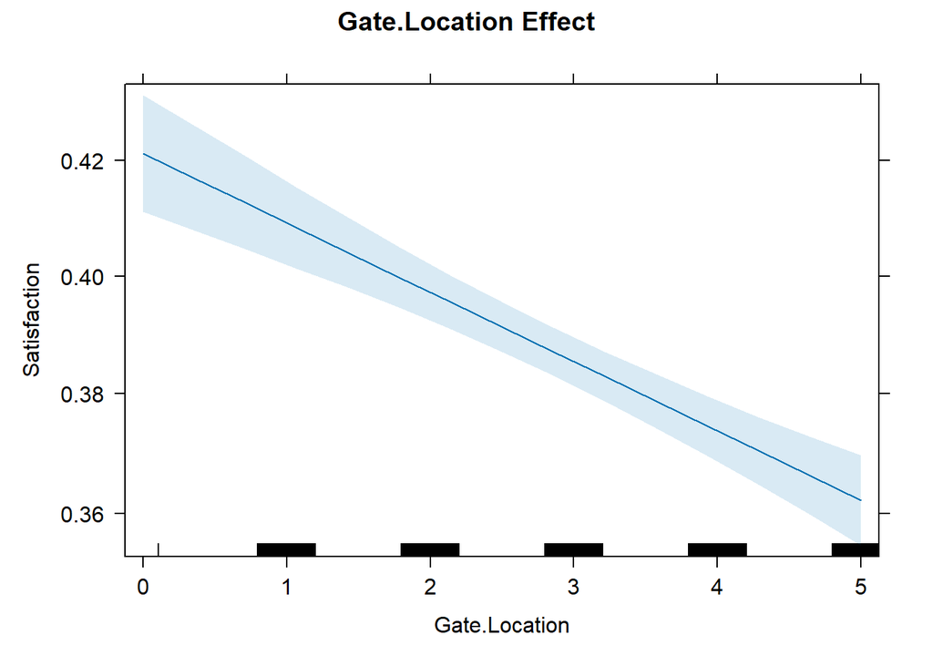

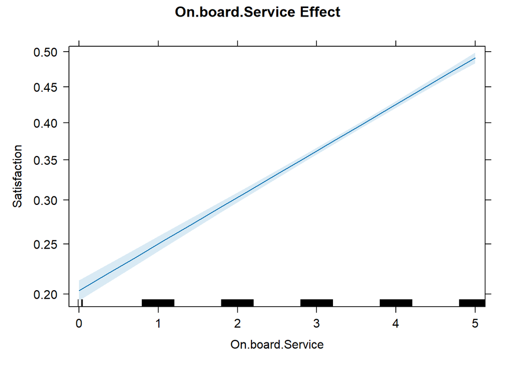

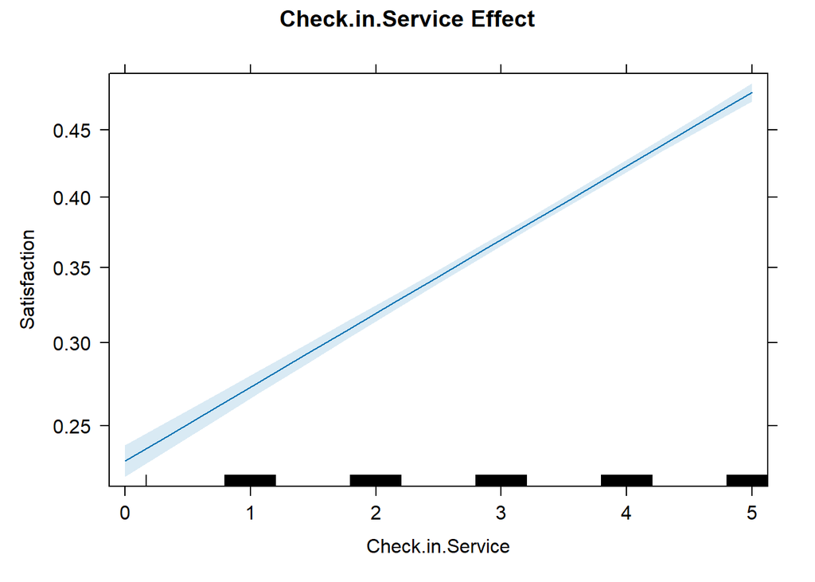

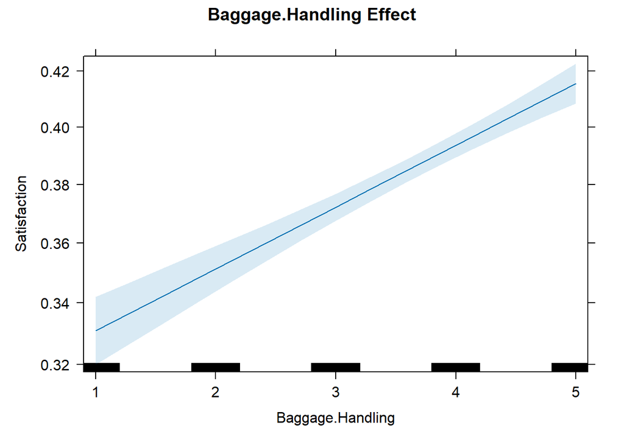

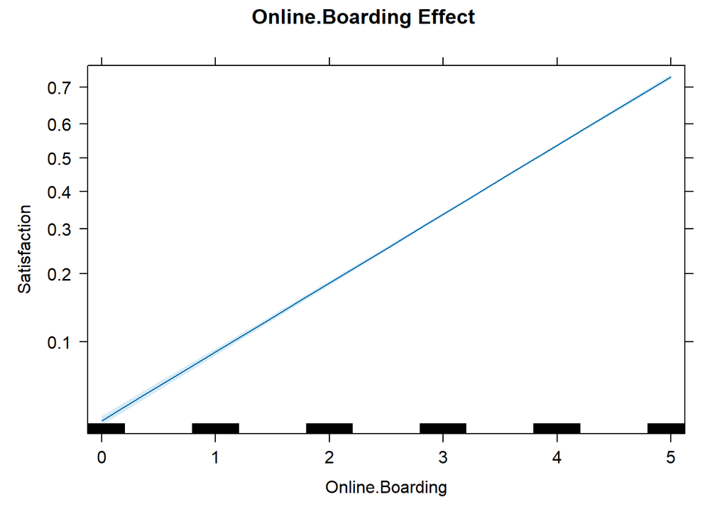

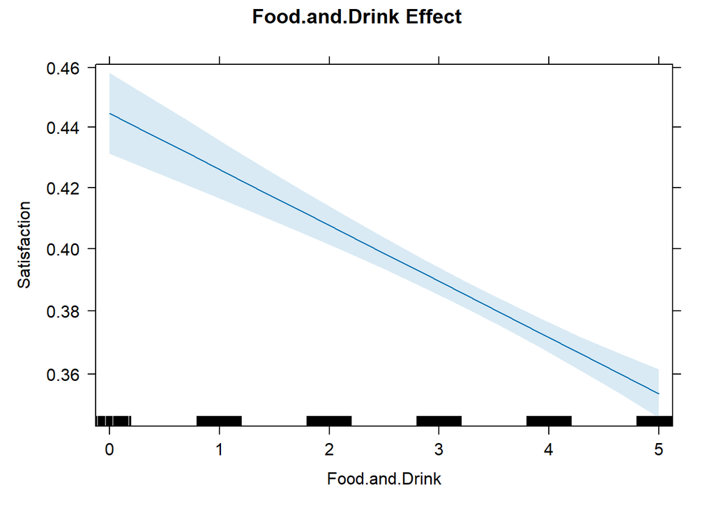

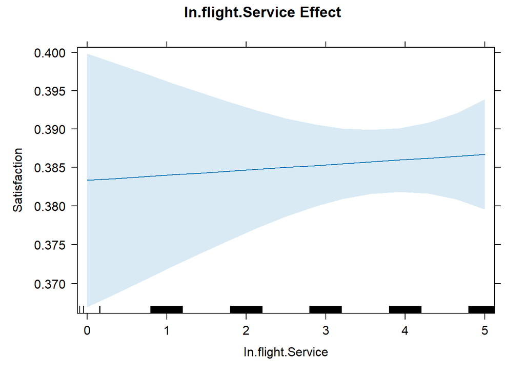

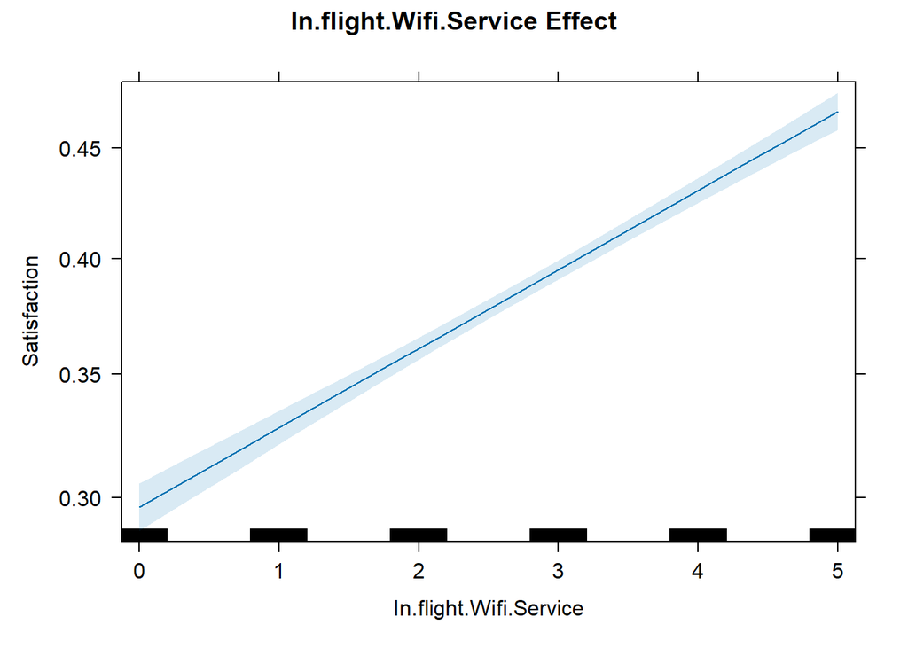

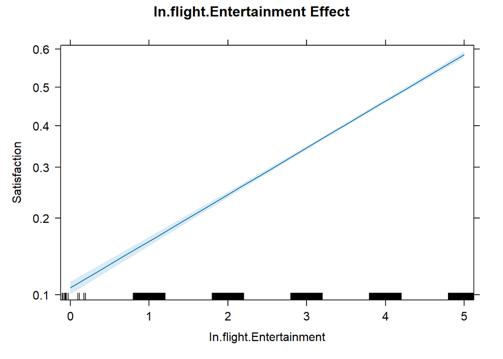

## 6.4 Airport Services + Customer and Travel Type + Comfort and Cleanliness

```r
AS_CTT_CC_model <- glm(Satisfaction ~  Gate.Location + On.board.Service + Baggage.Handling + Check.in.Service + Online.Boarding + Customer.Type + Type.of.Travel + Class + Seat.Comfort + Leg.Room.Service + Cleanliness, data = train, family = binomial)

summary(AS_CTT_CC_model)
```

```
##
## Call:
## glm(formula = Satisfaction ~ Gate.Location + On.board.Service +
##     Baggage.Handling + Check.in.Service + Online.Boarding + Customer.Type +
##     Type.of.Travel + Class + Seat.Comfort + Leg.Room.Service +
##     Cleanliness, family = binomial, data = train)
##
## Coefficients:
##                         Estimate Std. Error  z value Pr(>|z|)
## (Intercept)            -8.123147   0.068481 -118.619  < 2e-16 ***
## Gate.Location          -0.023003   0.007222   -3.185  0.00145 **
## On.board.Service        0.349256   0.009104   38.361  < 2e-16 ***
## Baggage.Handling        0.257502   0.009942   25.901  < 2e-16 ***
## Check.in.Service        0.291992   0.008116   35.978  < 2e-16 ***
## Online.Boarding         0.705584   0.008807   80.113  < 2e-16 ***
## Customer.TypeReturning  1.817287   0.025938   70.062  < 2e-16 ***
## Type.of.TravelPersonal -2.905902   0.029455  -98.656  < 2e-16 ***
## ClassEconomy           -0.524985   0.022785  -23.041  < 2e-16 ***
## ClassEconomy Plus      -0.576504   0.037796  -15.253  < 2e-16 ***
## Seat.Comfort            0.051118   0.010176    5.024 5.07e-07 ***
## Leg.Room.Service        0.292011   0.008093   36.083  < 2e-16 ***
## Cleanliness             0.265646   0.009718   27.337  < 2e-16 ***
## ---
## Signif. codes:  0 '***' 0.001 '**' 0.01 '*' 0.05 '.' 0.1 ' ' 1
##
## (Dispersion parameter for binomial family taken to be 1)
##
##     Null deviance: 141833  on 103611  degrees of freedom
## Residual deviance:  71847  on 103599  degrees of freedom
## AIC: 71873
##
## Number of Fisher Scoring iterations: 5
```

Below the execution of the test set with the current model:

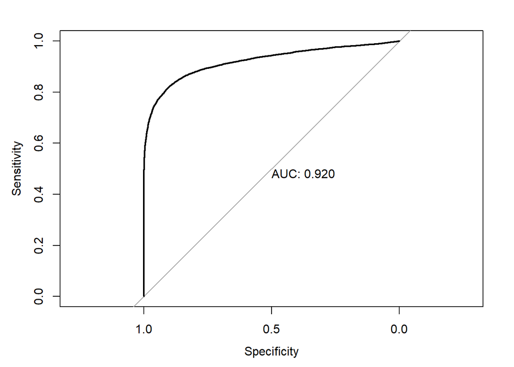

```r
AS_CTT_CC_model_probs <- predict(AS_CTT_CC_model, testX, type = "response")

AS_CTT_CC_model_roc <- roc(test$Satisfaction ~ AS_CTT_CC_model_probs, plot=TRUE, print.auc=TRUE)
```

Returns all information for the classification threshold of 0.5.

```r
coords(AS_CTT_CC_model_roc, x=0.5, ret="all")
```

```
##           threshold specificity sensitivity  accuracy    tn   tp   fn   fp
## threshold       0.5    0.905235   0.8171261 0.8668213 13211 9218 2063 1383
##                 npv       ppv       fdr        fpr       tpr      tnr       fnr
## threshold 0.8649339 0.8695406 0.1304594 0.09476497 0.8171261 0.905235 0.1828739
##           1-specificity 1-sensitivity 1-accuracy     1-npv     1-ppv precision
## threshold    0.09476497     0.1828739  0.1331787 0.1350661 0.1304594 0.8695406
##              recall   youden closest.topleft
## threshold 0.8171261 1.722361      0.04242325
```

Returns all information for the classification usign the best threshold.

```r
coords(AS_CTT_CC_model_roc, x="best", ret="all")
```

```
##           threshold specificity sensitivity  accuracy    tn   tp   fn   fp
## threshold 0.5022501   0.9066055   0.8160624 0.8671304 13231 9206 2075 1363
##                 npv       ppv       fdr        fpr       tpr       tnr
## threshold 0.8644322 0.8710379 0.1289621 0.09339455 0.8160624 0.9066055
##                 fnr 1-specificity 1-sensitivity 1-accuracy     1-npv     1-ppv
## threshold 0.1839376    0.09339455     0.1839376  0.1328696 0.1355678 0.1289621
##           precision    recall   youden closest.topleft
## threshold 0.8710379 0.8160624 1.722668      0.04255558
```

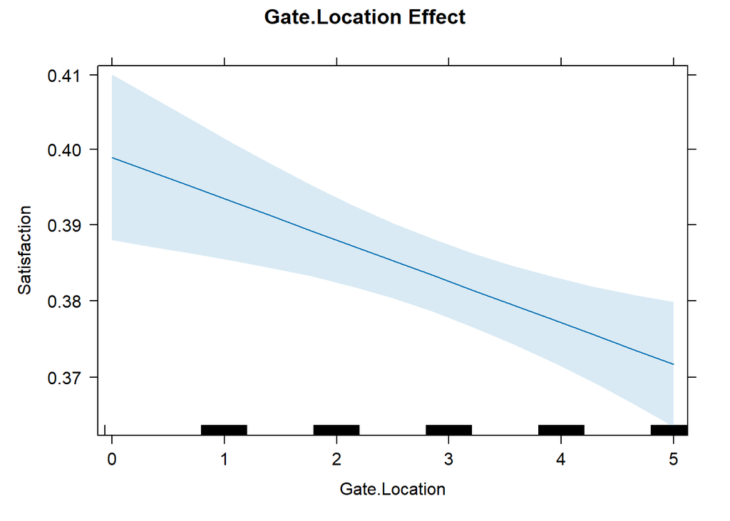

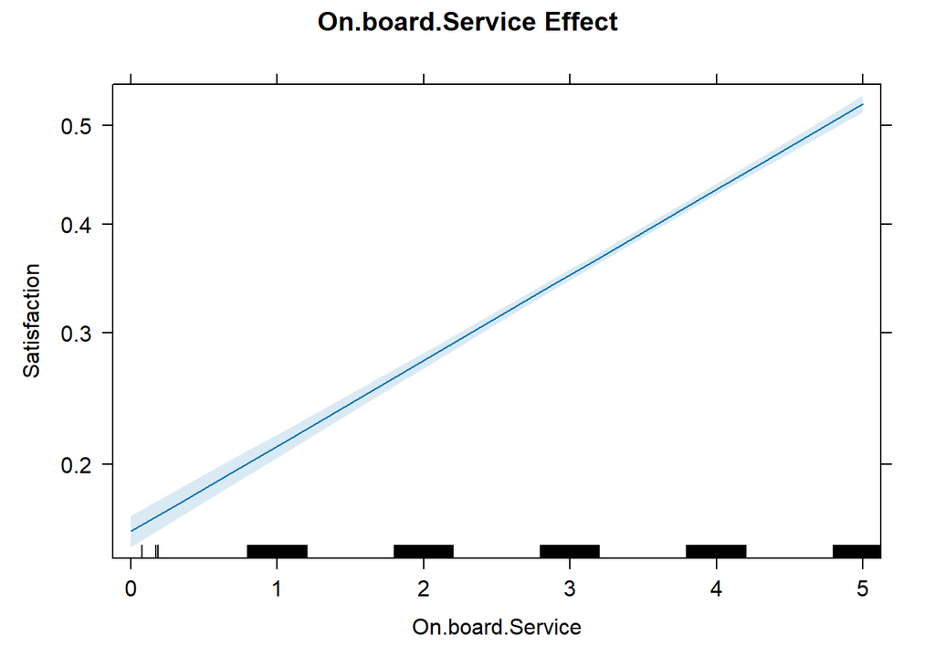

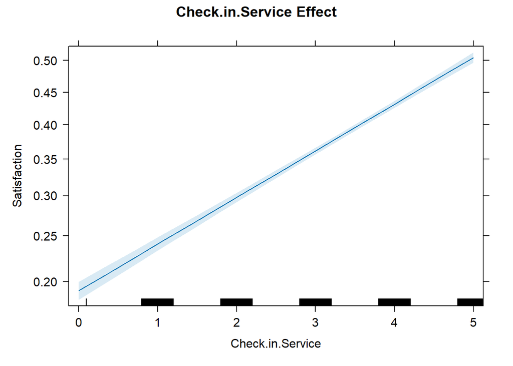

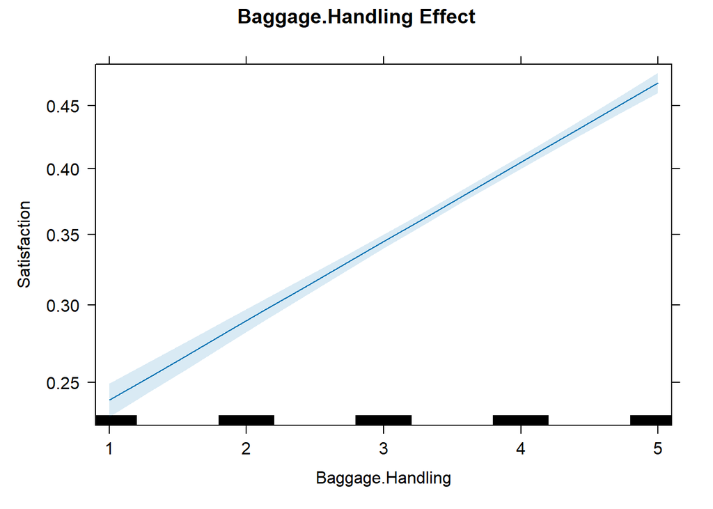

[figure not shown]

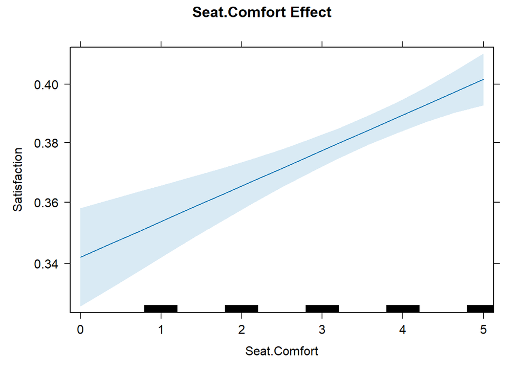

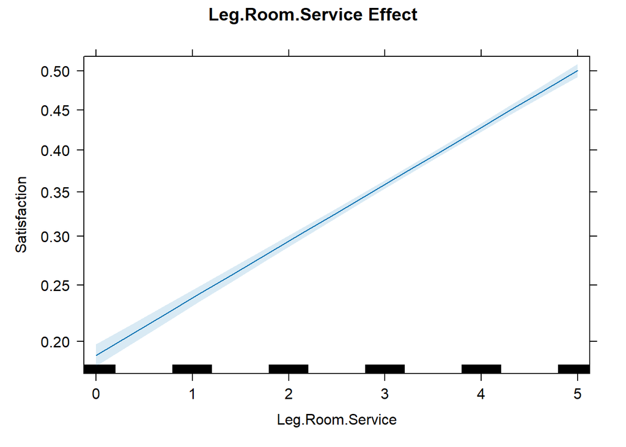

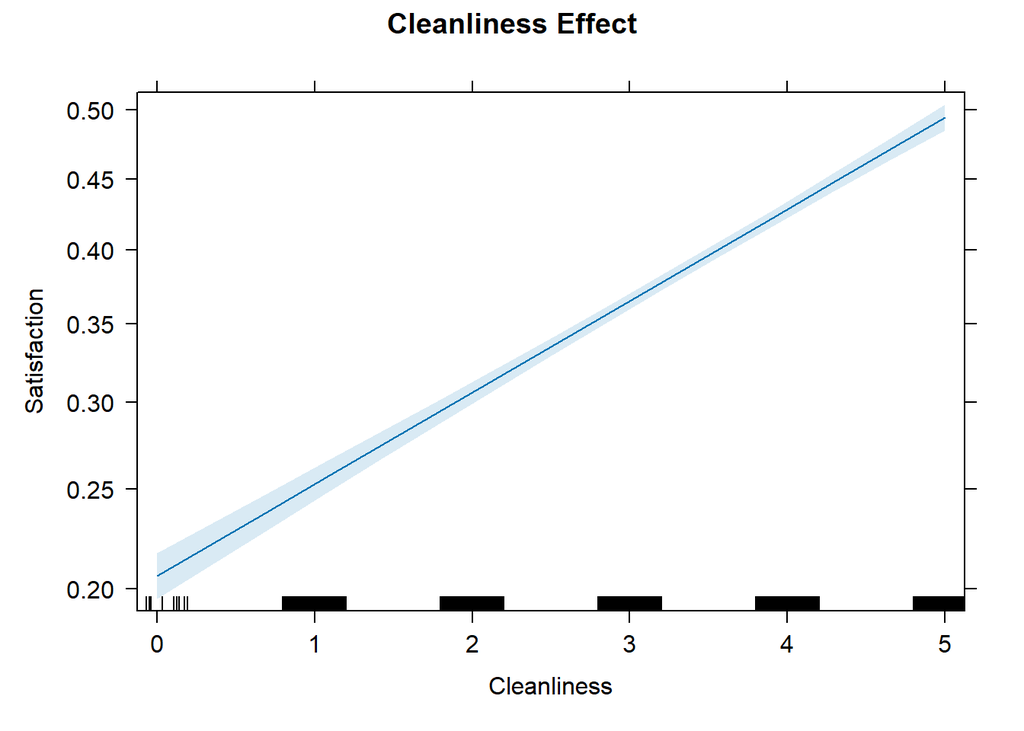

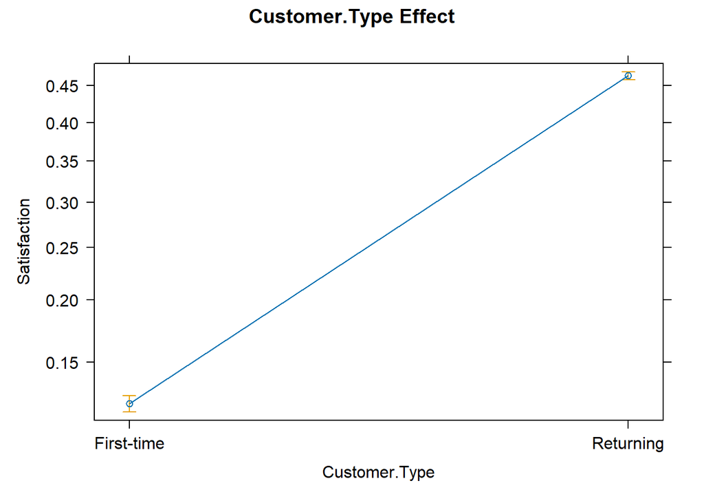

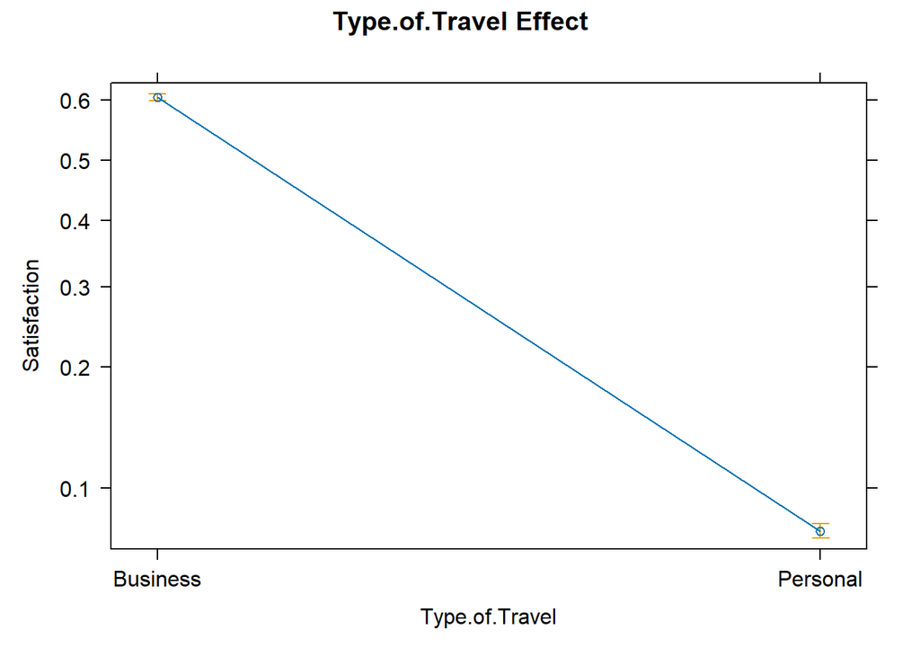

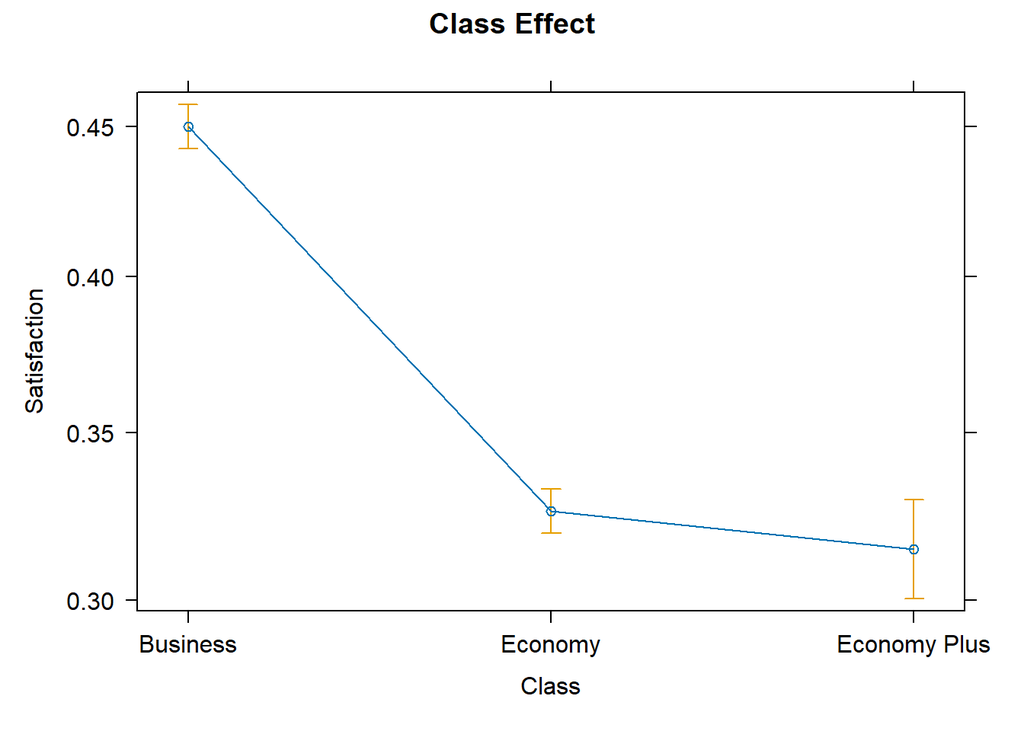

## 6.5 Airport Services + Customer and Travel Type + On-board Services

```r
AS_CTT_OBS_model <- glm(Satisfaction ~Gate.Location + On.board.Service + Baggage.Handling + Check.in.Service + Online.Boarding+ Customer.Type + Type.of.Travel + Class + Food.and.Drink + In.flight.Service + In.flight.Wifi.Service + In.flight.Entertainment , data = train, family = binomial)

summary(AS_CTT_OBS_model)
```

```
##
## Call:
## glm(formula = Satisfaction ~ Gate.Location + On.board.Service +
##     Baggage.Handling + Check.in.Service + Online.Boarding + Customer.Type +
##     Type.of.Travel + Class + Food.and.Drink + In.flight.Service +
##     In.flight.Wifi.Service + In.flight.Entertainment, family = binomial,
##     data = train)
##
## Coefficients:
##                          Estimate Std. Error  z value Pr(>|z|)
## (Intercept)             -7.458022   0.069228 -107.732   <2e-16 ***
## Gate.Location           -0.104865   0.007670  -13.671   <2e-16 ***
## On.board.Service         0.274343   0.009913   27.676   <2e-16 ***
## Baggage.Handling         0.165341   0.011089   14.911   <2e-16 ***
## Check.in.Service         0.357124   0.008252   43.275   <2e-16 ***
## Online.Boarding          0.601579   0.009311   64.608   <2e-16 ***
## Customer.TypeReturning   1.866888   0.026897   69.408   <2e-16 ***
## Type.of.TravelPersonal  -2.819421   0.030097  -93.678   <2e-16 ***
## ClassEconomy            -0.722063   0.023848  -30.278   <2e-16 ***
## ClassEconomy Plus       -0.809511   0.039305  -20.596   <2e-16 ***
## Food.and.Drink           0.024236   0.009714    2.495   0.0126 *
## In.flight.Service        0.123772   0.011602   10.668   <2e-16 ***
## In.flight.Wifi.Service   0.290706   0.008860   32.813   <2e-16 ***
## In.flight.Entertainment  0.285825   0.011446   24.972   <2e-16 ***
## ---
## Signif. codes:  0 '***' 0.001 '**' 0.01 '*' 0.05 '.' 0.1 ' ' 1
##
## (Dispersion parameter for binomial family taken to be 1)
##
##     Null deviance: 141833  on 103611  degrees of freedom
## Residual deviance:  71738  on 103598  degrees of freedom
## AIC: 71766
##
## Number of Fisher Scoring iterations: 5
```

Below the execution of the test set with the current model:

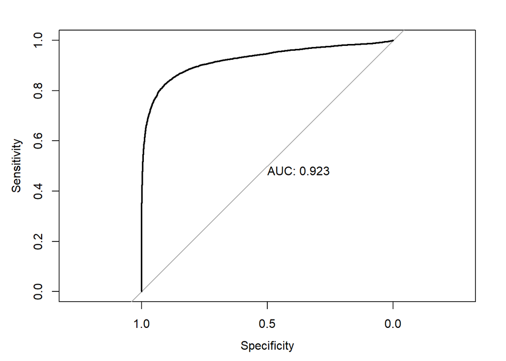

```r
AS_CTT_OBS_model_probs <- predict(AS_CTT_OBS_model, testX, type = "response")

AS_CTT_OBS_model_roc <- roc(test$Satisfaction ~ AS_CTT_OBS_model_probs, plot=TRUE, print.auc=TRUE)
```

Returns all information for the classification threshold of 0.5.

```r
coords(AS_CTT_OBS_model_roc, x=0.5, ret="all")
```

```
##           threshold specificity sensitivity accuracy    tn   tp   fn   fp
## threshold       0.5   0.9011237   0.8295364 0.869913 13151 9358 1923 1443
##                 npv       ppv       fdr        fpr       tpr       tnr
## threshold 0.8724293 0.8664013 0.1335987 0.09887625 0.8295364 0.9011237
##                 fnr 1-specificity 1-sensitivity 1-accuracy     1-npv     1-ppv
## threshold 0.1704636    0.09887625     0.1704636   0.130087 0.1275707 0.1335987
##           precision    recall  youden closest.topleft
## threshold 0.8664013 0.8295364 1.73066      0.03883436
```

Returns all information for the classification usign the best threshold.

```r
coords(AS_CTT_OBS_model_roc, x="best", ret="all")
```

```
##           threshold specificity sensitivity  accuracy    tn   tp   fn   fp
## threshold 0.5137489   0.9072907   0.8251928 0.8714976 13241 9309 1972 1353
##                npv       ppv       fdr        fpr       tpr       tnr       fnr
## threshold 0.870374 0.8731007 0.1268993 0.09270933 0.8251928 0.9072907 0.1748072
##           1-specificity 1-sensitivity 1-accuracy    1-npv     1-ppv precision
## threshold    0.09270933     0.1748072  0.1285024 0.129626 0.1268993 0.8731007
##              recall   youden closest.topleft
## threshold 0.8251928 1.732483      0.03915258
```

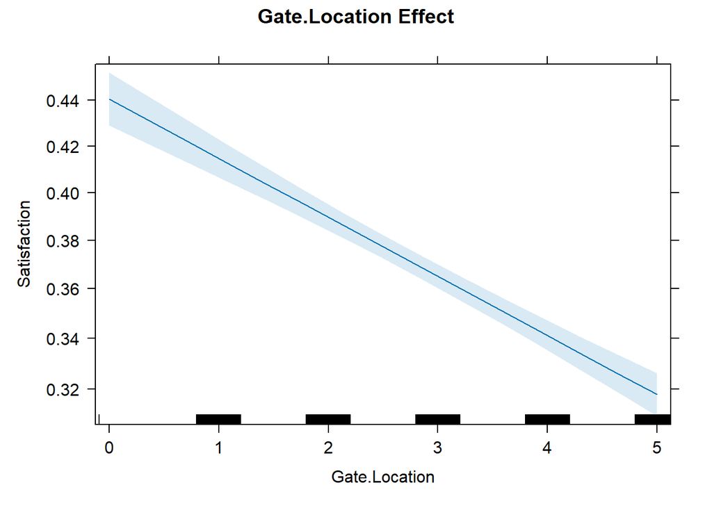

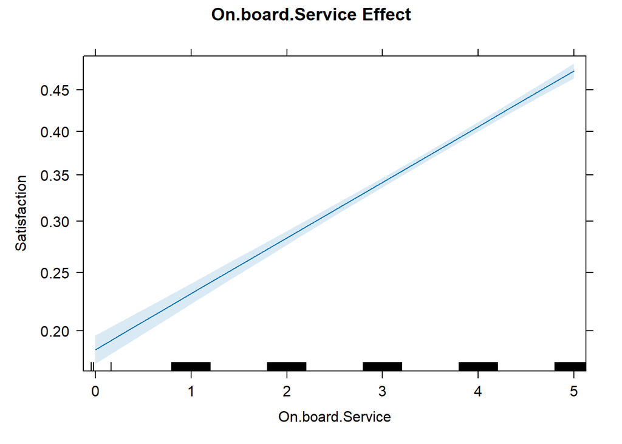

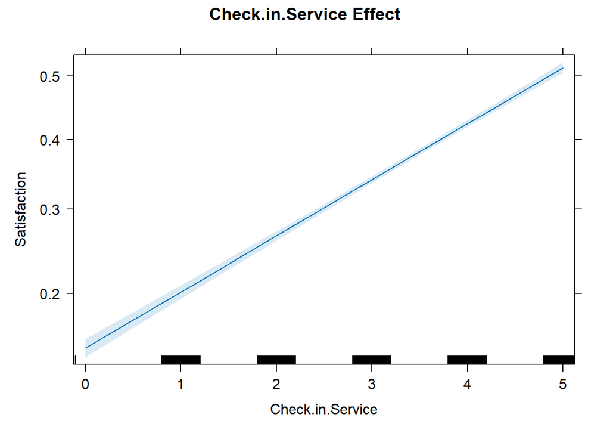

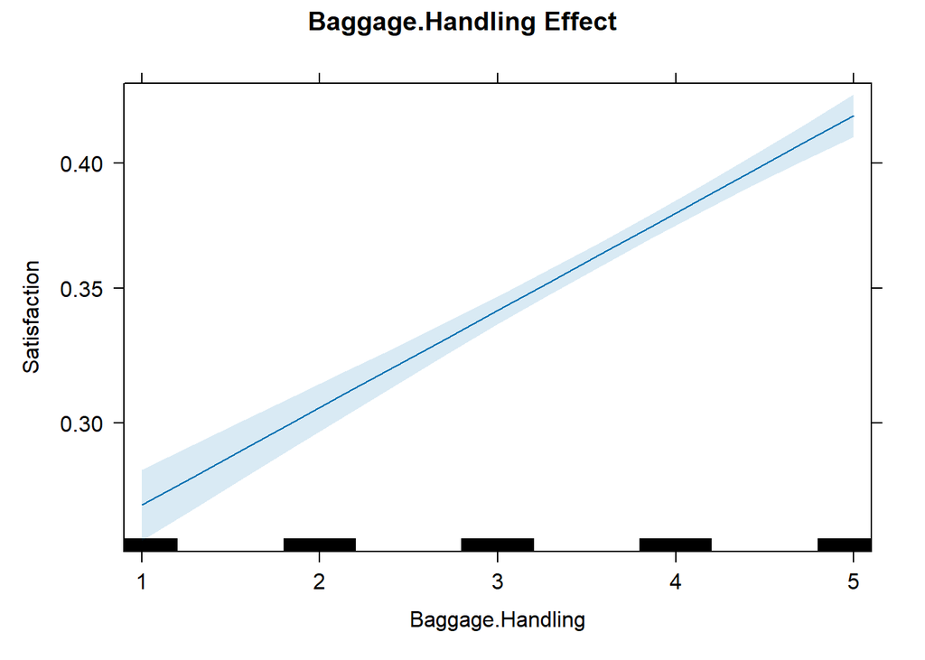

[figure not shown]

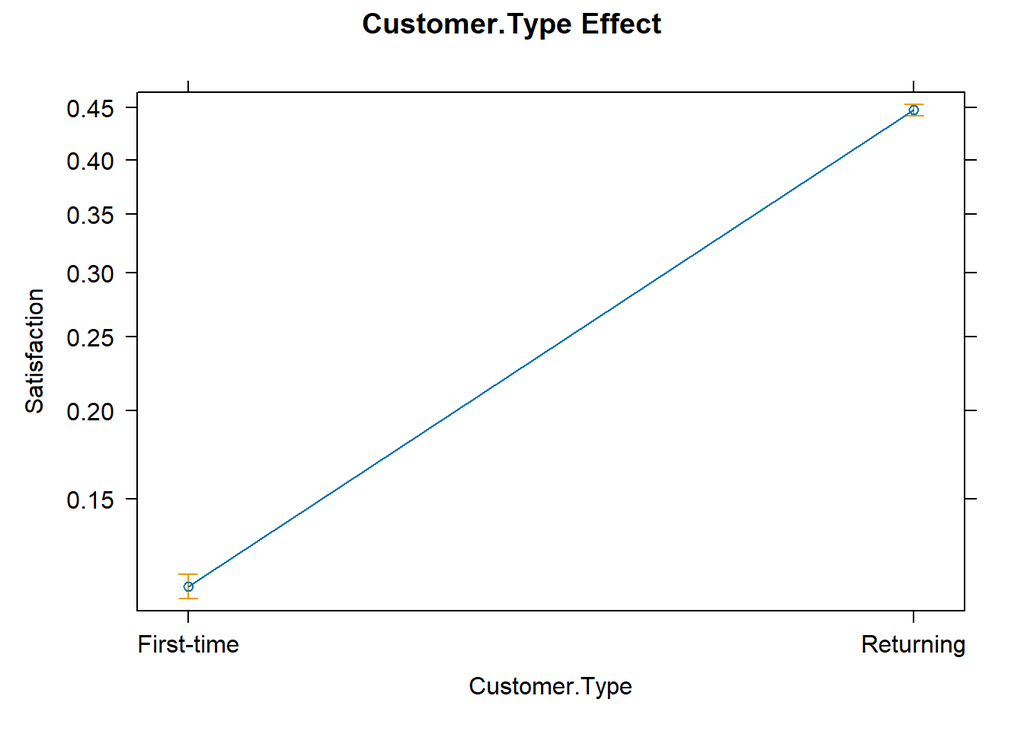

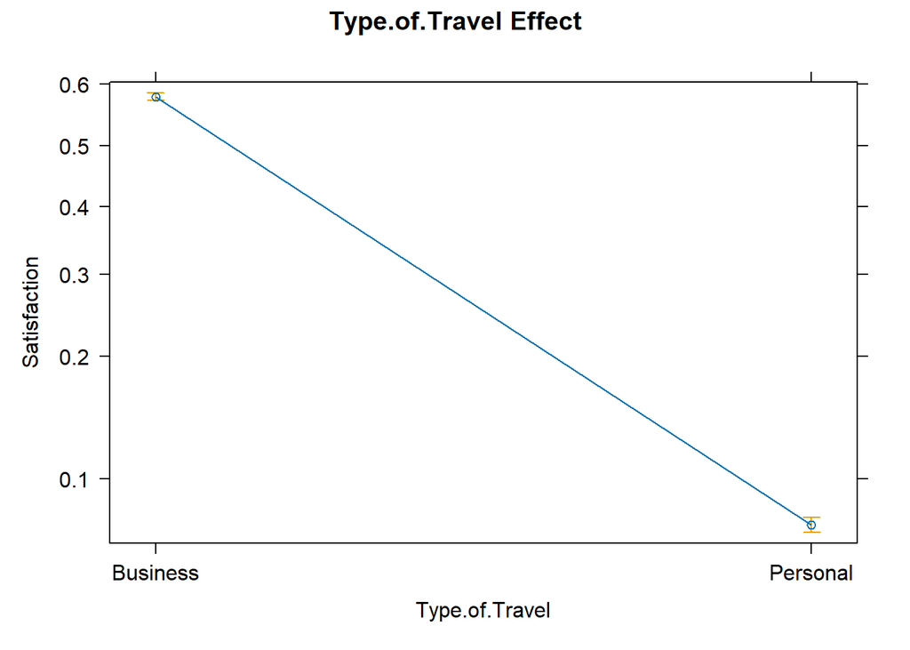

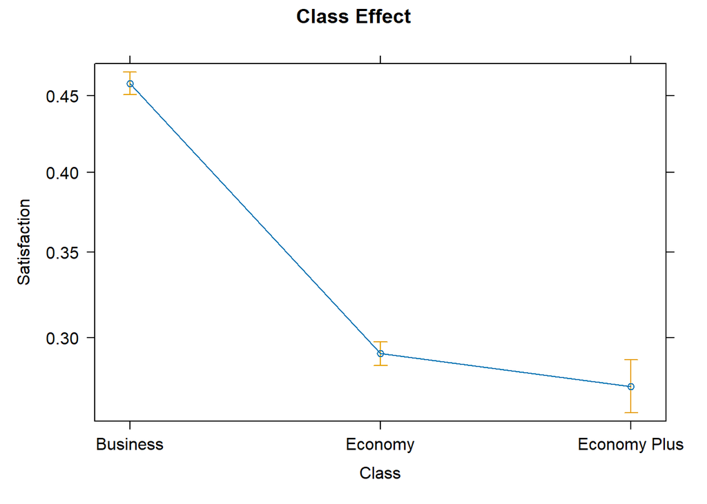

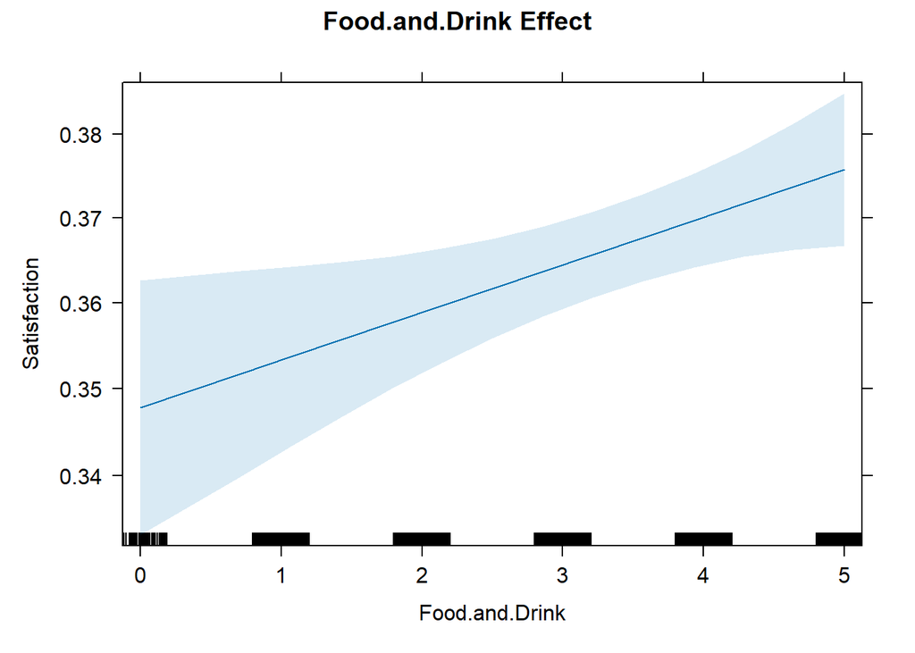

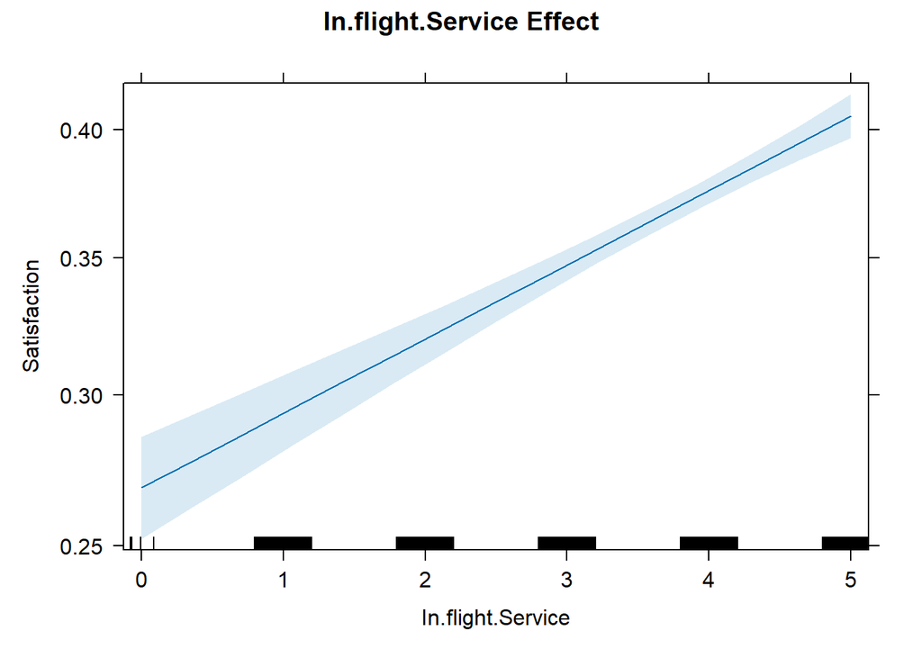

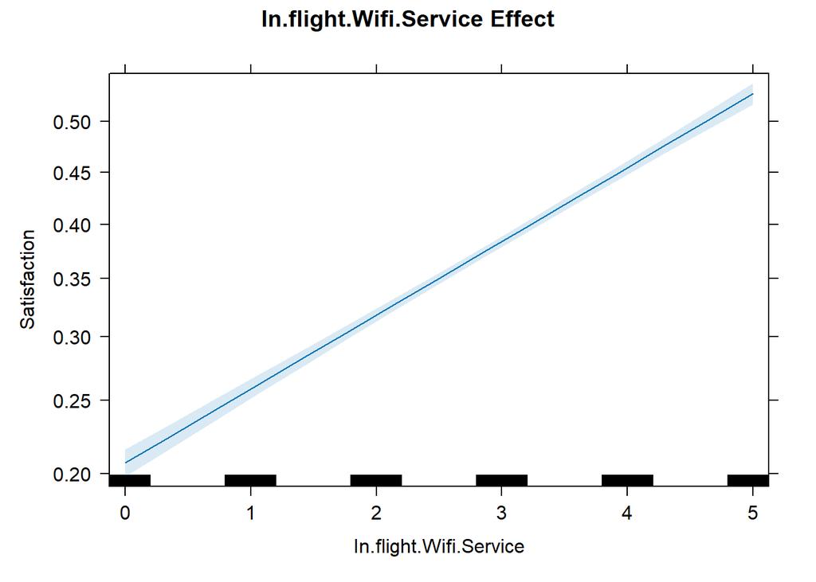

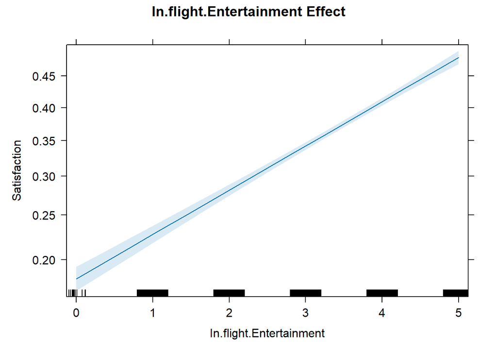

## 6.6 Model with all best predictor

```r
complete_model <- glm(Satisfaction ~ Customer.Type + Type.of.Travel + Class + Gate.Location + On.board.Service + Baggage.Handling + Check.in.Service + Online.Boarding + Food.and.Drink + In.flight.Service + In.flight.Wifi.Service + In.flight.Entertainment + Seat.Comfort + Leg.Room.Service + Cleanliness, data = train, family = binomial)

summary(complete_model)
```

```
##
## Call:
## glm(formula = Satisfaction ~ Customer.Type + Type.of.Travel +
##     Class + Gate.Location + On.board.Service + Baggage.Handling +
##     Check.in.Service + Online.Boarding + Food.and.Drink + In.flight.Service +
##     In.flight.Wifi.Service + In.flight.Entertainment + Seat.Comfort +
##     Leg.Room.Service + Cleanliness, family = binomial, data = train)
##
## Coefficients:
##                          Estimate Std. Error  z value Pr(>|z|)
## (Intercept)             -8.125179   0.073774 -110.135  < 2e-16 ***
## Customer.TypeReturning   1.879352   0.027230   69.018  < 2e-16 ***
## Type.of.TravelPersonal  -2.818852   0.030337  -92.916  < 2e-16 ***
## ClassEconomy            -0.678671   0.024028  -28.245  < 2e-16 ***
## ClassEconomy Plus       -0.764293   0.039424  -19.387  < 2e-16 ***
## Gate.Location           -0.098153   0.007734  -12.691  < 2e-16 ***
## On.board.Service         0.278891   0.010069   27.697  < 2e-16 ***
## Baggage.Handling         0.145638   0.011242   12.955  < 2e-16 ***
## Check.in.Service         0.317554   0.008436   37.641  < 2e-16 ***
## Online.Boarding          0.572392   0.009934   57.620  < 2e-16 ***
## Food.and.Drink          -0.021016   0.010466   -2.008   0.0447 *
## In.flight.Service        0.128073   0.011817   10.838  < 2e-16 ***
## In.flight.Wifi.Service   0.286367   0.009173   31.218  < 2e-16 ***
## In.flight.Entertainment  0.089214   0.013950    6.395 1.61e-10 ***
## Seat.Comfort             0.059362   0.011056    5.369 7.91e-08 ***
## Leg.Room.Service         0.234576   0.008419   27.863  < 2e-16 ***
## Cleanliness              0.223693   0.011828   18.912  < 2e-16 ***
## ---
## Signif. codes:  0 '***' 0.001 '**' 0.01 '*' 0.05 '.' 0.1 ' ' 1
##
## (Dispersion parameter for binomial family taken to be 1)
##
##     Null deviance: 141833  on 103611  degrees of freedom
## Residual deviance:  70516  on 103595  degrees of freedom
## AIC: 70550
##
## Number of Fisher Scoring iterations: 5
```

Below the execution of the test set with the current model:

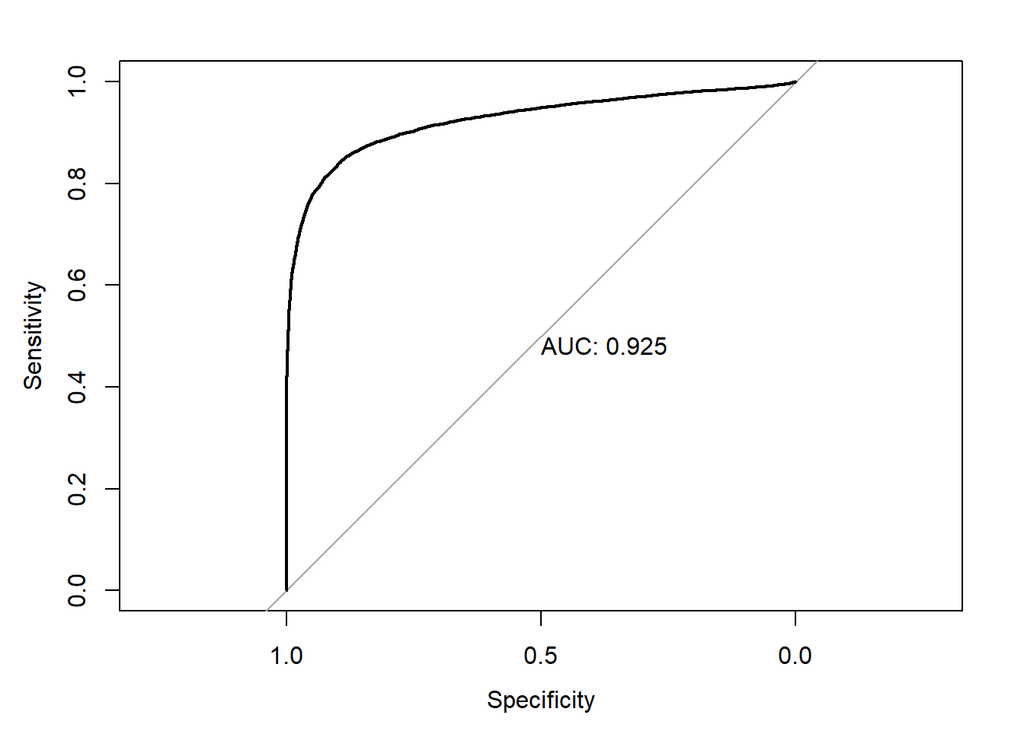

```r
complete_model_probs <- predict(complete_model, testX, type = "response")

complete_model_roc <- roc(test$Satisfaction ~ complete_model_probs, plot=TRUE, print.auc=TRUE)
```

Returns all information for the classification threshold of 0.5.

```r
coords(complete_model_roc, x=0.5, ret="all")
```

```
##           threshold specificity sensitivity  accuracy    tn   tp   fn   fp
## threshold       0.5   0.9048924   0.8300683 0.8722705 13206 9364 1917 1388
##                 npv       ppv       fdr        fpr       tpr       tnr
## threshold 0.8732394 0.8709077 0.1290923 0.09510758 0.8300683 0.9048924
##                 fnr 1-specificity 1-sensitivity 1-accuracy     1-npv     1-ppv
## threshold 0.1699317    0.09510758     0.1699317  0.1277295 0.1267606 0.1290923
##           precision    recall   youden closest.topleft
## threshold 0.8709077 0.8300683 1.734961      0.03792225
```

Returns all information for the classification usign the best threshold.

```r
coords(complete_model_roc, x="best", ret="all")
```

```
##           threshold specificity sensitivity  accuracy    tn   tp   fn   fp
## threshold 0.4753808   0.8963273   0.8407943 0.8721159 13081 9485 1796 1513
##                 npv       ppv       fdr       fpr       tpr       tnr       fnr
## threshold 0.8792767 0.8624295 0.1375705 0.1036727 0.8407943 0.8963273 0.1592057
##           1-specificity 1-sensitivity 1-accuracy     1-npv     1-ppv precision
## threshold     0.1036727     0.1592057  0.1278841 0.1207233 0.1375705 0.8624295
##              recall   youden closest.topleft
## threshold 0.8407943 1.737122      0.03609451
```

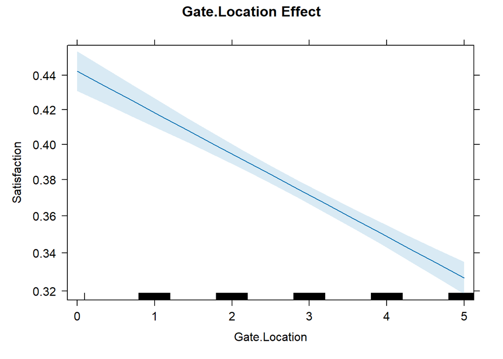

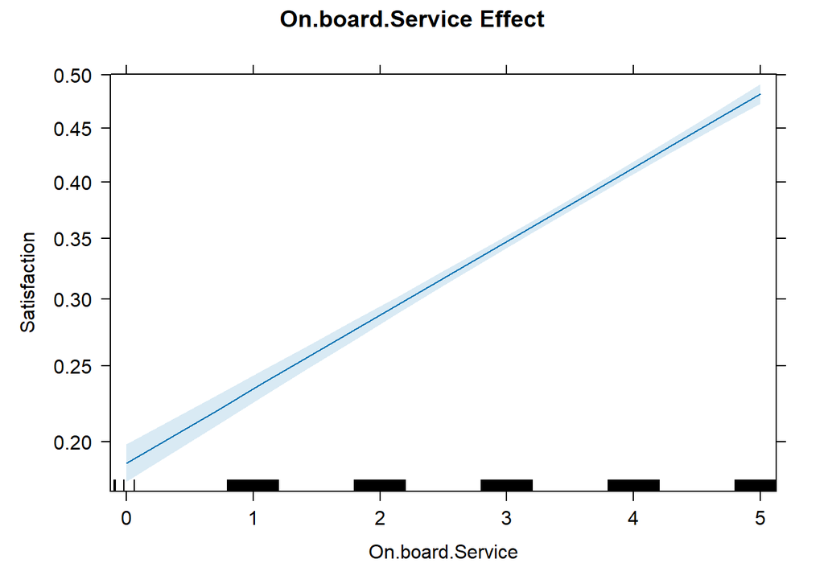